# SHARK TANK INDIA

### AREA ANALYSIS

```python
df["Pitchers State"].value_counts()
```

```
Maharashtra                  92
Delhi                        44
Karnataka                    34
Gujarat                      32
Haryana                      18
Uttar Pradesh                13
West Bengal                  13
Telangana                    12
Rajasthan                    11
Tamil Nadu                    8
Punjab                        8
Madhya Pradesh                5
Bihar                         4
Jammu & Kashmir               3
Goa                           3
Kerala                        2
Kerala,Maharashtra            1
Uttarakhand,Uttar Pradesh     1
Gujarat,Uttar Pradesh         1
Jharkhand,Chhattisgarh        1
Karnataka,Andhra Pradesh      1
Haryana,Maharashtra           1
Chhattisgarh                  1
Haryana,West Bengal           1
Uttarakhand                   1
Telangana,Maharashtra         1
Karnataka,Telangana           1
Jharkhand                     1
Himachal Pradesh              1
Haryana,Madhya Pradesh        1
Delhi,Maharashtra             1
Karnataka,West Bengal         1
Delhi,Punjab                  1
Arunachal Pradesh             1
Name: Pitchers State, dtype: int64
```

Observation:

From the above analysis we can see that Maharastra is the state from very most of participants participated in the show.

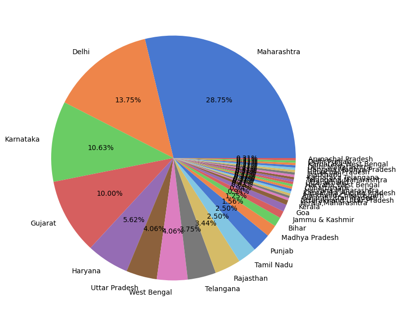

```python
plt.figure(figsize=(10,8))
plt.pie(x=df["Pitchers State"].value_counts().values,labels=df["Pitchers State"].value_counts().index,
        autopct="%.2f%%",colors=sns.color_palette("muted"));
```

The pie chart becomes cluttered when there are too many categories as states, so we do feature engineering to limit the number of categories.

```python
df["Pitchers State"].unique()
```

```
array(['Delhi', 'Gujarat', 'Karnataka', 'Punjab', 'Maharashtra',
       'Delhi,Punjab', 'Bihar', 'Telangana', 'Haryana', 'Kerala',
       'West Bengal', 'Tamil Nadu', 'Rajasthan', 'Madhya Pradesh',
       'Karnataka,West Bengal', 'Jammu & Kashmir', 'Uttar Pradesh',
       'Uttarakhand', 'Goa', 'Delhi,Maharashtra',
       'Haryana,Madhya Pradesh', 'Himachal Pradesh', 'Jharkhand',
       'Karnataka,Telangana', 'Telangana,Maharashtra',
       'Kerala,Maharashtra', 'Haryana,West Bengal', 'Chhattisgarh',
       'Haryana,Maharashtra', 'Karnataka,Andhra Pradesh',
       'Jharkhand,Chhattisgarh', 'Uttarakhand,Uttar Pradesh',
       'Gujarat,Uttar Pradesh', 'Arunachal Pradesh'], dtype=object)
```

We can observe from the above result that in some teams, each entrepreneur is from a different state, such as Karnataka and West Bengal, hence we are combining these states as follows.

```python
df1=df.copy()
```

```python
index=0
for i in df1["Pitchers State"]:
    if "," in i:
        df1.loc[index,"Pitchers State"]="hybrid state"
    else:
        df1.loc[index,"Pitchers State"]=i
    index=index+1
```

```python
df1.head(3)
```

|  | Season Number | Season Start | Season End | Episode Number | Episode Title | Pitch Number | Startup Name | Industry | Business Description | Number of Presenters | Male Presenters | Female Presenters | Transgender Presenters | Couple Presenters | Pitchers Average Age | Started in | Pitchers City | Pitchers State | Yearly Revenue | Monthly Sales | Gross Margin | Net Margin | Original Ask Amount | Original Offered Equity | Valuation Requested | Received Offer | Accepted Offer | Total Deal Amount | Total Deal Equity | … |
| --- | --- | --- | --- | --- | --- | --- | --- | --- | --- | --- | --- | --- | --- | --- | --- | --- | --- | --- | --- | --- | --- | --- | --- | --- | --- | --- | --- | --- | --- | --- |
| 0 | 1 | 20-Dec-21 | 4-Feb-22 | 1 | Badlegi Business Ki Tasveer | 1 | BluePineFoods | Food | Frozen Momos | 3 | 2.0 | 1.0 | 0.0 | 0.0 | Middle | 2016.0 | Delhi | Delhi | 95.0 | 8.0 | NaN | NaN | 50.0 | 5.0 | 1000.0 | 1 | 1.0 | 75.0 | 16.0 | … |
| 1 | 1 | 20-Dec-21 | 4-Feb-22 | 1 | Badlegi Business Ki Tasveer | 2 | BoozScooters | Vehicles/Electrical Vehicles | Renting e-bike for mobility in private spaces | 1 | 1.0 | 0.0 | 0.0 | 0.0 | Young | 2017.0 | Ahmedabad | Gujarat | 4.0 | 0.4 | NaN | NaN | 40.0 | 15.0 | 267.0 | 1 | 1.0 | 40.0 | 50.0 | … |
| 2 | 1 | 20-Dec-21 | 4-Feb-22 | 1 | Badlegi Business Ki Tasveer | 3 | HeartUpMySleeves | Beauty/Fashion | Detachable Sleeves | 1 | 0.0 | 1.0 | 0.0 | 0.0 | Young | 2021.0 | Delhi | Delhi | NaN | 2.0 | NaN | NaN | 25.0 | 10.0 | 250.0 | 1 | 1.0 | 25.0 | 30.0 | … |

```python
df1["Pitchers State"].unique()
```

```
array(['Delhi', 'Gujarat', 'Karnataka', 'Punjab', 'Maharashtra',
       'hybrid state', 'Bihar', 'Telangana', 'Haryana', 'Kerala',
       'West Bengal', 'Tamil Nadu', 'Rajasthan', 'Madhya Pradesh',
       'Jammu & Kashmir', 'Uttar Pradesh', 'Uttarakhand', 'Goa',
       'Himachal Pradesh', 'Jharkhand', 'Chhattisgarh',
       'Arunachal Pradesh'], dtype=object)
```

```
 [Text(0.6810033604166863, 0.8638486112167925, 'Maharashtra'),
 [Text(0.3714563784091016, 0.4711901515727958, '28.75%'),
```

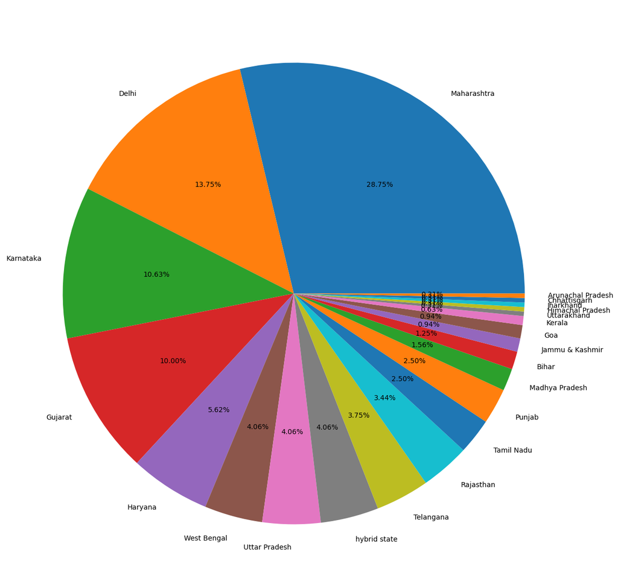

```python
plt.figure(figsize=(15,15))
plt.pie(x=df1["Pitchers State"].value_counts().values,
        labels=df1["Pitchers State"].value_counts().index,autopct="%.2f%%")
```

Still messiness is there in the above output, we further reduce the categories as below.

```python
l=["Madhya Pradesh","Bihar","Jammu & Kashmir","Goa","Kerala","Uttarakhand","Himachal Pradesh","Jharkhand","Chhattisgarh","Arunachal Pradesh"]
index=0
for i in df1["Pitchers State"]:
    if i in l:
        df1.loc[index,"Pitchers State"]="others"
    index=index+1
```

```python
df1["Pitchers State"].unique()
```

```
array(['Delhi', 'Gujarat', 'Karnataka', 'Punjab', 'Maharashtra',
       'hybrid state', 'others', 'Telangana', 'Haryana', 'West Bengal',
       'Tamil Nadu', 'Rajasthan', 'Uttar Pradesh'], dtype=object)
```

```python
df1["Pitchers State"].value_counts()
```

```
Maharashtra      92
Delhi            44
Karnataka        34
Gujarat          32
others           22
Haryana          18
hybrid state     13
West Bengal      13
Uttar Pradesh    13
Telangana        12
Rajasthan        11
Punjab            8
Tamil Nadu        8
Name: Pitchers State, dtype: int64
```

```
 [Text(0.6810033604166863, 0.8638486112167925, 'Maharashtra'),
 [Text(0.3714563784091016, 0.4711901515727958, '28.75%'),
```

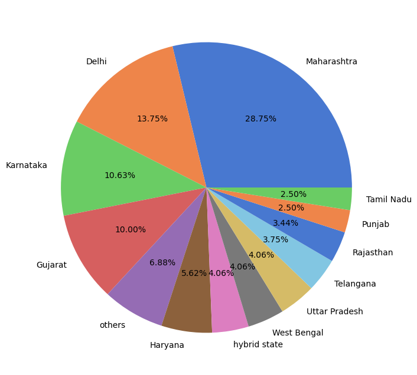

```python
plt.figure(figsize=(10,8))
plt.pie(x=df1["Pitchers State"].value_counts().values,
        labels=df1["Pitchers State"].value_counts().index,autopct="%.2f%%",colors=sns.color_palette("muted"))
```

### DISPLAYING TOP 5 PITCHERS STATE

```python
df1["Pitchers State"].value_counts().head(5)
```

```
Maharashtra    92
Delhi          44
Karnataka      34
Gujarat        32
others         22
Name: Pitchers State, dtype: int64
```

### IN RELATION TO THE PRECEDING STATES, THE MOST AND LEAST ACTIVE PARTICIPATING CITIES

```python
x=df1[((df1["Pitchers State"]=="Maharashtra")|(df["Pitchers State"]=="Delhi")|(df["Pitchers State"]=="Karnataka")|
       (df["Pitchers State"]=="Gujarat")|(df["Pitchers State"]=="others"))]
```

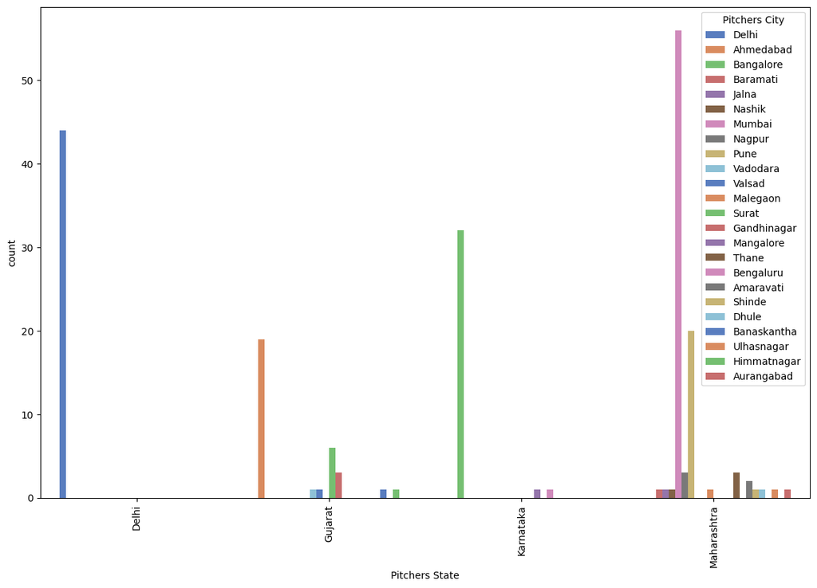

```python
plt.figure(figsize=(14,9))
sns.countplot(x="Pitchers State",data=x,hue="Pitchers City",palette="muted");
plt.xticks(rotation=90);
```

In Maharashtra , Mumbai is the city from where most participants participated

### HOW MANY ENTREPRENUERS PATENT THEIR IDEAS

```python
df["Has Patents"].value_counts()
```

```
1.0    7
Name: Has Patents, dtype: int64
```

```python
df[df["Has Patents"]==1]
```

|  | Season Number | Season Start | Season End | Episode Number | Episode Title | Pitch Number | Startup Name | Industry | Business Description | Number of Presenters | Male Presenters | Female Presenters | Transgender Presenters | Couple Presenters | Pitchers Average Age | Started in | Pitchers City | Pitchers State | Yearly Revenue | Monthly Sales | Gross Margin | Net Margin | Original Ask Amount | Original Offered Equity | Valuation Requested | Received Offer | Accepted Offer | Total Deal Amount | Total Deal Equity | … |
| --- | --- | --- | --- | --- | --- | --- | --- | --- | --- | --- | --- | --- | --- | --- | --- | --- | --- | --- | --- | --- | --- | --- | --- | --- | --- | --- | --- | --- | --- | --- |
| 205 | 2 | 2-Jan-23 | 10-Mar-23 | 18 | Business Ideas With Potential | 206 | Sayonara | Beauty/Fashion | Petticoat | 1 | 1.0 | 0.0 | 0.0 | 0.0 | Middle | NaN | Kolkata | West Bengal | 0.0 | NaN | NaN | NaN | 100.0 | 1.0 | 10000.0 | 0 | NaN | NaN | NaN | … |
| 245 | 2 | 2-Jan-23 | 10-Mar-23 | 31 | Innovations And Investments | 246 | Tipayi | Manufacturing | Balance Bike for Kids | 1 | 1.0 | 0.0 | 0.0 | 0.0 | Young | 2019.0 | Pune | Maharashtra | 21.0 | 0.5 | 35.0 | 26.0 | 50.0 | 10.0 | 500.0 | 1 | 0.0 | NaN | NaN | … |
| 266 | 2 | 2-Jan-23 | 10-Mar-23 | 37 | Bharat Ka Kal | 267 | Hornback | Vehicles/Electrical Vehicles | Diamond frame folding bicycles | 2 | 2.0 | 0.0 | 0.0 | 0.0 | Middle | NaN | Hyderabad | Telangana | NaN | NaN | NaN | NaN | 50.0 | 1.0 | 5000.0 | 1 | 1.0 | 50.0 | 2.5 | … |
| 268 | 2 | 2-Jan-23 | 10-Mar-23 | 37 | Bharat Ka Kal | 269 | nanoclean | Manufacturing | Contamination Control Solutions | 1 | 1.0 | 0.0 | 0.0 | 0.0 | Middle | 2017.0 | Bikaner | Rajasthan | 110.0 | 5.0 | NaN | NaN | 80.0 | 2.0 | 4000.0 | 0 | NaN | NaN | NaN | … |
| 281 | 2 | 2-Jan-23 | 10-Mar-23 | 41 | Out Of The Box Business Ideas | 282 | Trunome | Medical/Health | Post Transplant Care | 2 | 2.0 | 0.0 | 0.0 | 0.0 | Middle | NaN | Chennai | Tamil Nadu | NaN | NaN | NaN | NaN | 150.0 | 1.0 | 15000.0 | 1 | 1.0 | 150.0 | 2.0 | … |
| 297 | 2 | 2-Jan-23 | 10-Mar-23 | 45 | True Meaning Of Entrepreneurship | 298 | Subhag | Medical/Health | Health-tech IUI Treatment Procedure for Infert... | 3 | 3.0 | 0.0 | 0.0 | 0.0 | Middle | NaN | Jhumri Telaiya,Raipur | Jharkhand,Chhattisgarh | NaN | 0.0 | NaN | NaN | 50.0 | 1.0 | 5000.0 | 1 | 1.0 | 20.0 | 1.0 | … |
| 311 | 2 | 2-Jan-23 | 10-Mar-23 | 49 | Businesses Adding Value To Society | 312 | Sahayatha | Medical/Health | smart wheelchair with an assistive cleansing d... | 1 | 0.0 | 1.0 | 0.0 | 0.0 | Young | 2022.0 | Coimbatore | Tamil Nadu | NaN | NaN | NaN | NaN | 100.0 | 10.0 | 1000.0 | 1 | 1.0 | 100.0 | 10.0 | … |

### WHO ARE THEY ?

```python
df[df["Has Patents"]==1].iloc[:,[6,7,8,16,17]]
```

|  | Startup Name | Industry | Business Description | Pitchers City | Pitchers State |
| --- | --- | --- | --- | --- | --- |
| 205 | Sayonara | Beauty/Fashion | Petticoat | Kolkata | West Bengal |
| 245 | Tipayi | Manufacturing | Balance Bike for Kids | Pune | Maharashtra |
| 266 | Hornback | Vehicles/Electrical Vehicles | Diamond frame folding bicycles | Hyderabad | Telangana |
| 268 | nanoclean | Manufacturing | Contamination Control Solutions | Bikaner | Rajasthan |
| 281 | Trunome | Medical/Health | Post Transplant Care | Chennai | Tamil Nadu |
| 297 | Subhag | Medical/Health | Health-tech IUI Treatment Procedure for Infert... | Jhumri Telaiya,Raipur | Jharkhand,Chhattisgarh |
| 311 | Sahayatha | Medical/Health | smart wheelchair with an assistive cleansing d... | Coimbatore | Tamil Nadu |

### WHICH WAS THE OLDEST AND LATEST STARTUP PARTICIPATED IN SHARK TANK ?

```python
df["Started in"].min()
```

```
2005.0
```

```python
year=df[df["Started in"]!=0] ## 0 means no information
year.head(2)
```

|  | Season Number | Season Start | Season End | Episode Number | Episode Title | Pitch Number | Startup Name | Industry | Business Description | Number of Presenters | Male Presenters | Female Presenters | Transgender Presenters | Couple Presenters | Pitchers Average Age | Started in | Pitchers City | Pitchers State | Yearly Revenue | Monthly Sales | Gross Margin | Net Margin | Original Ask Amount | Original Offered Equity | Valuation Requested | Received Offer | Accepted Offer | Total Deal Amount | Total Deal Equity | … |
| --- | --- | --- | --- | --- | --- | --- | --- | --- | --- | --- | --- | --- | --- | --- | --- | --- | --- | --- | --- | --- | --- | --- | --- | --- | --- | --- | --- | --- | --- | --- |
| 0 | 1 | 20-Dec-21 | 4-Feb-22 | 1 | Badlegi Business Ki Tasveer | 1 | BluePineFoods | Food | Frozen Momos | 3 | 2.0 | 1.0 | 0.0 | 0.0 | Middle | 2016.0 | Delhi | Delhi | 95.0 | 8.0 | NaN | NaN | 50.0 | 5.0 | 1000.0 | 1 | 1.0 | 75.0 | 16.0 | … |
| 1 | 1 | 20-Dec-21 | 4-Feb-22 | 1 | Badlegi Business Ki Tasveer | 2 | BoozScooters | Vehicles/Electrical Vehicles | Renting e-bike for mobility in private spaces | 1 | 1.0 | 0.0 | 0.0 | 0.0 | Young | 2017.0 | Ahmedabad | Gujarat | 4.0 | 0.4 | NaN | NaN | 40.0 | 15.0 | 267.0 | 1 | 1.0 | 40.0 | 50.0 | … |

```python
year[year["Started in"]==year["Started in"].min()]
```

|  | Season Number | Season Start | Season End | Episode Number | Episode Title | Pitch Number | Startup Name | Industry | Business Description | Number of Presenters | Male Presenters | Female Presenters | Transgender Presenters | Couple Presenters | Pitchers Average Age | Started in | Pitchers City | Pitchers State | Yearly Revenue | Monthly Sales | Gross Margin | Net Margin | Original Ask Amount | Original Offered Equity | Valuation Requested | Received Offer | Accepted Offer | Total Deal Amount | Total Deal Equity | … |
| --- | --- | --- | --- | --- | --- | --- | --- | --- | --- | --- | --- | --- | --- | --- | --- | --- | --- | --- | --- | --- | --- | --- | --- | --- | --- | --- | --- | --- | --- | --- |
| 5 | 1 | 20-Dec-21 | 4-Feb-22 | 2 | Insaan, Ideas Aur Sapne | 6 | Agritourism | Agriculture | Tourism | 2 | 1.0 | 1.0 | 0.0 | 1.0 | Middle | 2005.0 | Baramati | Maharashtra | 79.0 | NaN | NaN | NaN | 50.0 | 5.0 | 1000.0 | 0 | NaN | NaN | NaN | … |

Startup name : Agritourism

Started in : 2005

### LATEST YEAR IS 2022

```python
year[year["Started in"]==year["Started in"].max()]["Yearly Revenue"].max()
```

```
1600.0
```

```python
year[year["Yearly Revenue"]==1600]
```

|  | Season Number | Season Start | Season End | Episode Number | Episode Title | Pitch Number | Startup Name | Industry | Business Description | Number of Presenters | Male Presenters | Female Presenters | Transgender Presenters | Couple Presenters | Pitchers Average Age | Started in | Pitchers City | Pitchers State | Yearly Revenue | Monthly Sales | Gross Margin | Net Margin | Original Ask Amount | Original Offered Equity | Valuation Requested | Received Offer | Accepted Offer | Total Deal Amount | Total Deal Equity | … |
| --- | --- | --- | --- | --- | --- | --- | --- | --- | --- | --- | --- | --- | --- | --- | --- | --- | --- | --- | --- | --- | --- | --- | --- | --- | --- | --- | --- | --- | --- | --- |
| 230 | 2 | 2-Jan-23 | 10-Mar-23 | 26 | Bharat Badal Raha Hai | 231 | UnStop | Technology/Software | Connecting talent colleges recruiters | 1 | 1.0 | 0.0 | 0.0 | 0.0 | Middle | 2022.0 | Delhi | Delhi | 1600.0 | NaN | 90.0 | NaN | 100.0 | 1.0 | 10000.0 | 1 | 1.0 | 200.0 | 4.0 | … |

```python
year[year["Started in"]==year["Started in"].max()]["Yearly Revenue"].min()
```

```
-1.0
```

```python
year[year["Yearly Revenue"]==-1]
```

|  | Season Number | Season Start | Season End | Episode Number | Episode Title | Pitch Number | Startup Name | Industry | Business Description | Number of Presenters | Male Presenters | Female Presenters | Transgender Presenters | Couple Presenters | Pitchers Average Age | Started in | Pitchers City | Pitchers State | Yearly Revenue | Monthly Sales | Gross Margin | Net Margin | Original Ask Amount | Original Offered Equity | Valuation Requested | Received Offer | Accepted Offer | Total Deal Amount | Total Deal Equity | … |
| --- | --- | --- | --- | --- | --- | --- | --- | --- | --- | --- | --- | --- | --- | --- | --- | --- | --- | --- | --- | --- | --- | --- | --- | --- | --- | --- | --- | --- | --- | --- |
| 137 | 1 | 20-Dec-21 | 4-Feb-22 | 0 | Unseen | 138 | ZyppElectric | Vehicles/Electrical Vehicles | Electrical Vehicles | 2 | 1.0 | 1.0 | 0.0 | 1.0 | Young | NaN | Gurgaon | Haryana | -1.0 | NaN | NaN | NaN | 220.0 | 1.00 | 22000.000000 | 0 | NaN | NaN | NaN | … |
| 140 | 1 | 20-Dec-21 | 4-Feb-22 | 0 | Unseen | 141 | HappyBar | Food | FitSport delicious snacks | 3 | 2.0 | 1.0 | 0.0 | 0.0 | Middle | 2019.0 | Hyderabad | Telangana | -1.0 | 29.0 | NaN | NaN | 60.0 | 2.00 | 3000.000000 | 0 | NaN | NaN | NaN | … |
| 157 | 2 | 2-Jan-23 | 10-Mar-23 | 2 | A Bigger Vision | 158 | SoupX | Food | Soup based meals | 2 | 2.0 | 0.0 | 0.0 | 0.0 | Young | NaN | Delhi | Delhi | -1.0 | NaN | 45.0 | NaN | 75.0 | 6.00 | 1250.000000 | 1 | 1.0 | 50.0 | 18.00 | … |
| 165 | 2 | 2-Jan-23 | 10-Mar-23 | 5 | Investing in the Future of India | 166 | Flatheads | Beauty/Fashion | Shoes Sneakers Loafers | 1 | 1.0 | 0.0 | 0.0 | 0.0 | Middle | 2019.0 | Bangalore | Karnataka | -1.0 | NaN | NaN | NaN | 75.0 | 3.00 | 2500.000000 | 1 | 0.0 | NaN | NaN | … |
| 194 | 2 | 2-Jan-23 | 10-Mar-23 | 15 | Changing The Face Of Indian Entrepreneurship | 195 | FastBeetle | Services | Local courier and parcel service | 2 | 2.0 | 0.0 | 0.0 | 0.0 | Young | 2019.0 | Srinagar | Jammu & Kashmir | -1.0 | 25.0 | 54.0 | NaN | 90.0 | 3.00 | 3000.000000 | 1 | 1.0 | 90.0 | 7.50 | … |
| 196 | 2 | 2-Jan-23 | 10-Mar-23 | 16 | Pitchers Ki Taiyyari | 197 | VSMani | Food | Coffee and snacks | 3 | 3.0 | 0.0 | 0.0 | 0.0 | Middle | 2020.0 | Bangalore | Karnataka | -1.0 | 63.0 | NaN | NaN | 60.0 | 1.50 | 4000.000000 | 1 | 1.0 | 19.0 | 1.00 | … |
| 208 | 2 | 2-Jan-23 | 10-Mar-23 | 19 | Building Brands For India | 209 | Bullspree | Technology/Software | App to learn stock market basics | 3 | 3.0 | 0.0 | 0.0 | 0.0 | Middle | NaN | Ahmedabad | Gujarat | -1.0 | NaN | NaN | NaN | 75.0 | 1.50 | 5000.000000 | 1 | 1.0 | 75.0 | 2.86 | … |
| 214 | 2 | 2-Jan-23 | 10-Mar-23 | 21 | Adhbhut Aur Anokhe Entrepreneurs | 215 | CloudTailor | Services | Custom tailor online | 3 | 2.0 | 1.0 | 0.0 | 1.0 | Middle | NaN | Bangalore,Hyderabad | Karnataka,Telangana | -1.0 | 34.0 | NaN | NaN | 100.0 | 1.40 | 7142.857143 | 0 | NaN | NaN | NaN | … |
| 219 | 2 | 2-Jan-23 | 10-Mar-23 | 23 | Changing The World | 220 | PadCare | Manufacturing | Menstrual hygiene disposal solution | 1 | 1.0 | 0.0 | 0.0 | 0.0 | Young | NaN | Pune | Maharashtra | -1.0 | 14.0 | NaN | NaN | 50.0 | 2.00 | 2500.000000 | 1 | 1.0 | 100.0 | 4.00 | … |
| 232 | 2 | 2-Jan-23 | 10-Mar-23 | 27 | Nayi Soch Naye Vichaar | 233 | TheGreenSnack | Food | Healthy Snacks Online | 2 | 1.0 | 1.0 | 0.0 | 1.0 | Middle | 2017.0 | Mumbai | Maharashtra | -1.0 | 25.0 | NaN | NaN | 100.0 | 2.00 | 5000.000000 | 1 | 1.0 | 100.0 | 8.00 | … |
| 241 | 2 | 2-Jan-23 | 10-Mar-23 | 29 | Pulse Of The Country | 242 | Barosi | Food | Fresh & pure milk products | 1 | 1.0 | 0.0 | 0.0 | 0.0 | Middle | 2016.0 | Pataudi | Haryana | -1.0 | 42.0 | 40.0 | NaN | 50.0 | 2.00 | 2500.000000 | 0 | NaN | NaN | NaN | … |
| 247 | 2 | 2-Jan-23 | 10-Mar-23 | 31 | Innovations And Investments | 248 | Nirmalaya | Manufacturing | Incense products made from temple flowers | 3 | 2.0 | 1.0 | 0.0 | 1.0 | Middle | NaN | Delhi | Delhi | -1.0 | 80.0 | NaN | NaN | 60.0 | 1.50 | 4000.000000 | 0 | NaN | NaN | NaN | … |
| 253 | 2 | 2-Jan-23 | 10-Mar-23 | 33 | Growing With India | 254 | TheHealthyBinge | Food | Assorted Pack Baked Chips | 2 | 2.0 | 0.0 | 0.0 | 0.0 | Middle | NaN | Pune | Maharashtra | -1.0 | 11.0 | NaN | NaN | 50.0 | 5.00 | 1000.000000 | 1 | 1.0 | 50.0 | 5.00 | … |
| 254 | 2 | 2-Jan-23 | 10-Mar-23 | 33 | Growing With India | 255 | Freakins | Beauty/Fashion | Fashionable Denim Apparel | 2 | 2.0 | 0.0 | 0.0 | 0.0 | Middle | NaN | Mumbai | Maharashtra | -1.0 | NaN | 63.0 | NaN | 70.0 | 1.00 | 7000.000000 | 1 | 1.0 | 50.0 | 2.50 | … |
| 255 | 2 | 2-Jan-23 | 10-Mar-23 | 34 | Growing Ideas Into Successful Businesses | 256 | Perfora | Furnishing/Household | Toothpaste Electric Toothbrush | 2 | 2.0 | 0.0 | 0.0 | 0.0 | Young | NaN | Ballarpur,Karnal | Haryana,Maharashtra | -1.0 | NaN | 57.0 | NaN | 80.0 | 1.00 | 8000.000000 | 1 | 1.0 | 80.0 | 2.50 | … |
| 262 | 2 | 2-Jan-23 | 10-Mar-23 | 36 | Anokhe Pitchers Ke Anokhe Ideas | 263 | neuphony | Medical/Health | Wearable EEG Headband | 2 | 1.0 | 1.0 | 0.0 | 1.0 | Young | 2022.0 | Noida | Uttar Pradesh | -1.0 | NaN | NaN | NaN | 100.0 | 2.00 | 5000.000000 | 1 | 1.0 | 100.0 | 5.40 | … |
| 273 | 2 | 2-Jan-23 | 10-Mar-23 | 39 | Revolutionary Ideas And Successful Businesses | 274 | GladFul | Food | Natural High Protein Rich & Healthy Foods | 2 | 1.0 | 1.0 | 0.0 | 0.0 | Middle | 2022.0 | Jaipur | Rajasthan | -1.0 | 24.0 | NaN | NaN | 50.0 | 2.00 | 2500.000000 | 1 | 1.0 | 50.0 | 3.50 | … |
| 279 | 2 | 2-Jan-23 | 10-Mar-23 | 40 | Creating Valuable Businesses | 280 | GROWiT | Agriculture | Protective farming products | 2 | 2.0 | 0.0 | 0.0 | 0.0 | Middle | NaN | Surat | Gujarat | -1.0 | NaN | 22.0 | NaN | 100.0 | 1.00 | 10000.000000 | 1 | 1.0 | 50.0 | 1.00 | … |
| 284 | 2 | 2-Jan-23 | 10-Mar-23 | 42 | Building Businesses From Scratch | 285 | ProostBeer | Liquor/Beverages | Freshly brewed beer | 2 | 2.0 | 0.0 | 0.0 | 0.0 | Middle | 2018.0 | Delhi | Delhi | -1.0 | NaN | NaN | NaN | 100.0 | 0.75 | 13333.333330 | 0 | NaN | NaN | NaN | … |
| 292 | 2 | 2-Jan-23 | 10-Mar-23 | 44 | Entrepreneurship Ka Junoon | 293 | HealthyMaster | Food | Online Dry Fruits, Snacks, Berries, Chips | 3 | 1.0 | 2.0 | 0.0 | 1.0 | Middle | 2019.0 | Bangalore | Karnataka | -1.0 | 20.0 | 45.0 | NaN | 50.0 | 2.00 | 2500.000000 | 1 | 1.0 | 50.0 | 6.50 | … |
| 302 | 2 | 2-Jan-23 | 10-Mar-23 | 46 | Different Colours Of Entrepreneurship | 303 | TheHealthyFactory | Food | Protein bread | 2 | 2.0 | 0.0 | 0.0 | 0.0 | Young | 2018.0 | Mumbai | Maharashtra | -1.0 | NaN | 56.0 | NaN | 75.0 | 2.10 | 3571.428571 | 0 | NaN | NaN | NaN | … |
| 309 | 2 | 2-Jan-23 | 10-Mar-23 | 48 | Pitchers, Investments And Businesses | 310 | LilGoodness | Food | Healthy Snacks | 2 | 2.0 | 0.0 | 0.0 | 0.0 | Middle | 2020.0 | Bangalore | Karnataka | -1.0 | 145.0 | 65.0 | NaN | 100.0 | 1.00 | 10000.000000 | 1 | 1.0 | 50.0 | 1.00 | … |
| 312 | 2 | 2-Jan-23 | 10-Mar-23 | 49 | Businesses Adding Value To Society | 313 | WickedGud | Food | High Protein & Fiber Gluten Free Vegan food | 3 | 3.0 | 0.0 | 0.0 | 0.0 | Middle | 2021.0 | Mumbai | Maharashtra | -1.0 | NaN | NaN | NaN | 50.0 | 1.00 | 5000.000000 | 0 | NaN | NaN | NaN | … |
| 315 | 2 | 2-Jan-23 | 10-Mar-23 | 50 | Season Finale With The Sharks | 316 | MYBYK | Vehicles/Electrical Vehicles | IoT-enabled bikes | 1 | 1.0 | 0.0 | 0.0 | 0.0 | Middle | NaN | Ahmedabad | Gujarat | -1.0 | NaN | NaN | NaN | 200.0 | 1.00 | 20000.000000 | 0 | NaN | NaN | NaN | … |
| 316 | 2 | 2-Jan-23 | 10-Mar-23 | 51 | Gateway To Shark Tank India | 317 | GODESi | Food | Handmade lollipops | 2 | 1.0 | 1.0 | 0.0 | 0.0 | Middle | NaN | Bangalore | Karnataka | -1.0 | 270.0 | NaN | NaN | 90.0 | 0.50 | 18000.000000 | 1 | 0.0 | NaN | NaN | … |
| 317 | 2 | 2-Jan-23 | 10-Mar-23 | 51 | Gateway To Shark Tank India | 318 | TAC | Beauty/Fashion | ayurveda co for glowing skin, makeup & open pores | 2 | 1.0 | 1.0 | 0.0 | 1.0 | Middle | NaN | Mumbai | Maharashtra | -1.0 | NaN | NaN | NaN | 150.0 | 0.50 | 30000.000000 | 1 | 1.0 | 81.0 | 1.00 | … |

### INSIGHTS:

```python
df.head(1)
```

|  | Season Number | Season Start | Season End | Episode Number | Episode Title | Pitch Number | Startup Name | Industry | Business Description | Number of Presenters | Male Presenters | Female Presenters | Transgender Presenters | Couple Presenters | Pitchers Average Age | Started in | Pitchers City | Pitchers State | Yearly Revenue | Monthly Sales | Gross Margin | Net Margin | Original Ask Amount | Original Offered Equity | Valuation Requested | Received Offer | Accepted Offer | Total Deal Amount | Total Deal Equity | … |
| --- | --- | --- | --- | --- | --- | --- | --- | --- | --- | --- | --- | --- | --- | --- | --- | --- | --- | --- | --- | --- | --- | --- | --- | --- | --- | --- | --- | --- | --- | --- |
| 0 | 1 | 20-Dec-21 | 4-Feb-22 | 1 | Badlegi Business Ki Tasveer | 1 | BluePineFoods | Food | Frozen Momos | 3 | 2.0 | 1.0 | 0.0 | 0.0 | Middle | 2016.0 | Delhi | Delhi | 95.0 | 8.0 | NaN | NaN | 50.0 | 5.0 | 1000.0 | 1 | 1.0 | 75.0 | 16.0 | … |

### HOW MANY DEALS WERE FINALISED?

```python
df["Accepted Offer"].value_counts()
```

```
1.0    176
0.0     40
Name: Accepted Offer, dtype: int64
```

### INSIGHTS :

176 offers were accepted

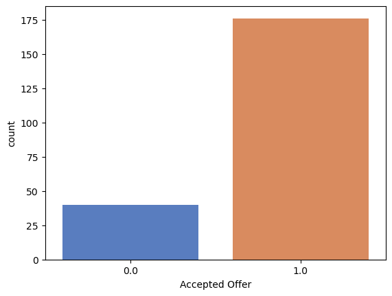

```python
sns.countplot(x="Accepted Offer",data=df,palette="muted")
```

### THE IDEAS AND DETAILS OF BRANDS WHO WERE ACCEPTED

```python
df_ac=df[df["Accepted Offer"]==1]
df_ac[["Startup Name","Industry","Business Description"]]
```

|  | Startup Name | Industry | Business Description |
| --- | --- | --- | --- |
| 0 | BluePineFoods | Food | Frozen Momos |
| 1 | BoozScooters | Vehicles/Electrical Vehicles | Renting e-bike for mobility in private spaces |
| 2 | HeartUpMySleeves | Beauty/Fashion | Detachable Sleeves |
| 3 | TagzFoods | Food | Healthy Potato Chips Snacks |
| 7 | Peeschute | Beauty/Fashion | Disposable Urine Bag |
| 8 | NOCD | Food | Energy Drink |
| 9 | CosIQ | Beauty/Fashion | Intelligent Skincare |
| 10 | JhaJiAchaar | Food | Pickle |
| 11 | Bummer | Beauty/Fashion | Underwear |
| 12 | RevampMoto | Vehicles/Electrical Vehicles | E-Bike Mitra bud-e RM |
| 15 | SkippiIcePops | Food | Ice-Pops |
| 16 | Menstrupedia | Education | Menstrual Awareness Comic |
| 18 | RaisingSuperstars | Education | Child Development App |
| 20 | Kavach | Education | Report bullying incidents |
| 22 | BeyondSnack | Food | Kerala Banana Chips |
| 23 | VivalyfInnovations | Medical/Health | Easy Life Prickless Diabetes Testing Machine |
| 24 | MotionBreeze | Vehicles/Electrical Vehicles | Smart Electric Motorcycle |
| 25 | Altor | Manufacturing | Smart Helmets |
| 26 | Ariro | Manufacturing | Wooden Toys |
| 28 | Nuutjob | Beauty/Fashion | Male Intimate Hygiene deo spray |
| 29 | Meatyour | Food | Eggs |
| 30 | EventBeep | Education | Student Community App EdTech |
| 32 | ARRCOATSurfaceTextures | Manufacturing | Wall Building Surface Textures |
| 33 | Farda | Beauty/Fashion | Customised Streetwear |
| 34 | Auli | Beauty/Fashion | Ayurvedic Products Skincare Lifestyle |
| 36 | LOKA | Technology/Software | Metaverse App |
| 37 | Annie | Education | Thinkerbell labs Braille Literary Device |
| 38 | Carragreen | Manufacturing | Eco-Friendly boxes |
| 39 | TheYarnBazaar | Manufacturing | Yarn-Trading App Online Marketplace for Yarn |
| 40 | TheRenalProject | Medical/Health | Home Dialysis Treatment |

[output cut: 146 more lines]

### HOW MANY DEALS WERE FINALISED IN BOTH THE SEASONS?

```python
df.groupby(["Season Number"])["Accepted Offer"].value_counts()
```

```
Season Number  Accepted Offer
1              1.0                70
               0.0                26
2              1.0               106
               0.0                14
Name: Accepted Offer, dtype: int64
```

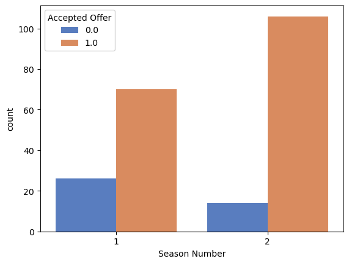

```python
sns.countplot(x="Season Number",data=df,palette="muted",hue="Accepted Offer")
```

```
 [Text(0.5774742805727675, 0.9362283136484202, '(1, 1.0)'),
 [Text(0.3149859712215095, 0.5106699892627746, '32.41%'),
```

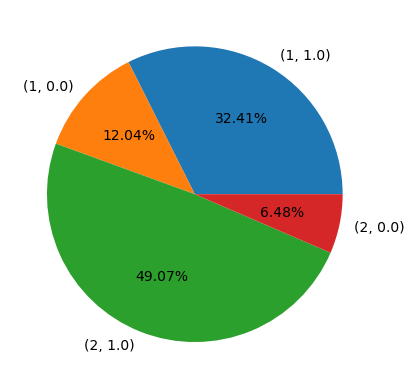

```python
plt.pie(x=df.groupby(["Season Number"])["Accepted Offer"].value_counts().values,
        labels=df.groupby(["Season Number"])["Accepted Offer"].value_counts().index,autopct="%.2f%%")
```

### INSIGHTS :

```python
df_ac=df[df["Accepted Offer"]==1]
df[["Startup Name","Industry","Business Description"]]
```

|  | Startup Name | Industry | Business Description |
| --- | --- | --- | --- |
| 0 | BluePineFoods | Food | Frozen Momos |
| 1 | BoozScooters | Vehicles/Electrical Vehicles | Renting e-bike for mobility in private spaces |
| 2 | HeartUpMySleeves | Beauty/Fashion | Detachable Sleeves |
| 3 | TagzFoods | Food | Healthy Potato Chips Snacks |
| 4 | HeadAndHeart | Education | Brain Development Course |
| 5 | Agritourism | Agriculture | Tourism |
| 6 | qZenseLabs | Food | Food Freshness Detector |
| 7 | Peeschute | Beauty/Fashion | Disposable Urine Bag |
| 8 | NOCD | Food | Energy Drink |
| 9 | CosIQ | Beauty/Fashion | Intelligent Skincare |
| 10 | JhaJiAchaar | Food | Pickle |
| 11 | Bummer | Beauty/Fashion | Underwear |
| 12 | RevampMoto | Vehicles/Electrical Vehicles | E-Bike Mitra bud-e RM |
| 13 | HungryHead | Food | Restaurant serving 80 types of Maggi |
| 14 | ShrawaniEngineers | Beauty/Fashion | Belly Button Shaper |
| 15 | SkippiIcePops | Food | Ice-Pops |
| 16 | Menstrupedia | Education | Menstrual Awareness Comic |
| 17 | Hecoll | Beauty/Fashion | Pollution Resistant Fabric - Healthy Cover For... |
| 18 | RaisingSuperstars | Education | Child Development App |
| 19 | Torch-it | Education | Gadgets for visually impaired people |
| 20 | Kavach | Education | Report bullying incidents |
| 21 | LaKheerDeli | Food | Kheer in variety of flavors |
| 22 | BeyondSnack | Food | Kerala Banana Chips |
| 23 | VivalyfInnovations | Medical/Health | Easy Life Prickless Diabetes Testing Machine |
| 24 | MotionBreeze | Vehicles/Electrical Vehicles | Smart Electric Motorcycle |
| 25 | Altor | Manufacturing | Smart Helmets |
| 26 | Ariro | Manufacturing | Wooden Toys |
| 27 | KabiraHandmad | Food | Healthy Edible Oils dairy products spices flour |
| 28 | Nuutjob | Beauty/Fashion | Male Intimate Hygiene deo spray |
| 29 | Meatyour | Food | Eggs |

[output cut: 290 more lines]

### HOW MANY OFFERS WERE REJECTED ?

```python
len(df[df["Received Offer"]!=df["Accepted Offer"]])
```

```
144
```

```python
df[df["Received Offer"]!=df["Accepted Offer"]]
```

|  | Season Number | Season Start | Season End | Episode Number | Episode Title | Pitch Number | Startup Name | Industry | Business Description | Number of Presenters | Male Presenters | Female Presenters | Transgender Presenters | Couple Presenters | Pitchers Average Age | Started in | Pitchers City | Pitchers State | Yearly Revenue | Monthly Sales | Gross Margin | Net Margin | Original Ask Amount | Original Offered Equity | Valuation Requested | Received Offer | Accepted Offer | Total Deal Amount | Total Deal Equity | … |
| --- | --- | --- | --- | --- | --- | --- | --- | --- | --- | --- | --- | --- | --- | --- | --- | --- | --- | --- | --- | --- | --- | --- | --- | --- | --- | --- | --- | --- | --- | --- |
| 4 | 1 | 20-Dec-21 | 4-Feb-22 | 2 | Insaan, Ideas Aur Sapne | 5 | HeadAndHeart | Education | Brain Development Course | 4 | 1.0 | 3.0 | 0.0 | 1.0 | Middle | 2015.0 | Patiala | Punjab | 30.0 | NaN | NaN | NaN | 50.0 | 5.00 | 1000.000000 | 0 | NaN | NaN | NaN | … |
| 5 | 1 | 20-Dec-21 | 4-Feb-22 | 2 | Insaan, Ideas Aur Sapne | 6 | Agritourism | Agriculture | Tourism | 2 | 1.0 | 1.0 | 0.0 | 1.0 | Middle | 2005.0 | Baramati | Maharashtra | 79.0 | NaN | NaN | NaN | 50.0 | 5.00 | 1000.000000 | 0 | NaN | NaN | NaN | … |
| 6 | 1 | 20-Dec-21 | 4-Feb-22 | 3 | Aam Aadmi Ke Business Ideas | 7 | qZenseLabs | Food | Food Freshness Detector | 2 | 0.0 | 2.0 | 0.0 | 0.0 | Middle | 2020.0 | Delhi,Mohali | Delhi,Punjab | 25.0 | NaN | NaN | NaN | 100.0 | 0.25 | 40000.000000 | 1 | 0.0 | NaN | NaN | … |
| 13 | 1 | 20-Dec-21 | 4-Feb-22 | 5 | Hunt For Interesting Business | 14 | HungryHead | Food | Restaurant serving 80 types of Maggi | 2 | 2.0 | 0.0 | 0.0 | 0.0 | Middle | 2013.0 | Mumbai | Maharashtra | NaN | 5.50 | NaN | NaN | 50.0 | 5.00 | 1000.000000 | 0 | NaN | NaN | NaN | … |
| 14 | 1 | 20-Dec-21 | 4-Feb-22 | 5 | Hunt For Interesting Business | 15 | ShrawaniEngineers | Beauty/Fashion | Belly Button Shaper | 2 | 1.0 | 1.0 | 0.0 | 1.0 | Middle | 2019.0 | Nagpur | Maharashtra | 50.0 | NaN | NaN | NaN | 20.0 | 10.00 | 200.000000 | 0 | NaN | NaN | NaN | … |
| 17 | 1 | 20-Dec-21 | 4-Feb-22 | 6 | New Week, New Ideas | 18 | Hecoll | Beauty/Fashion | Pollution Resistant Fabric - Healthy Cover For... | 1 | 0.0 | 1.0 | 0.0 | 0.0 | Middle | 2019.0 | Hyderabad | Telangana | 107.0 | NaN | NaN | NaN | 100.0 | 1.00 | 10000.000000 | 0 | NaN | NaN | NaN | … |
| 19 | 1 | 20-Dec-21 | 4-Feb-22 | 7 | A Never Give Up Spirit | 20 | Torch-it | Education | Gadgets for visually impaired people | 1 | 1.0 | 0.0 | 0.0 | 0.0 | Middle | 2018.0 | Ahmedabad | Gujarat | NaN | 1.00 | NaN | NaN | 75.0 | 1.00 | 7500.000000 | 1 | 0.0 | NaN | NaN | … |
| 21 | 1 | 20-Dec-21 | 4-Feb-22 | 7 | A Never Give Up Spirit | 22 | LaKheerDeli | Food | Kheer in variety of flavors | 3 | 1.0 | 2.0 | 0.0 | 0.0 | Middle | NaN | Pune | Maharashtra | NaN | 6.00 | NaN | NaN | 50.0 | 7.50 | 667.000000 | 1 | 0.0 | NaN | NaN | … |
| 27 | 1 | 20-Dec-21 | 4-Feb-22 | 9 | Defining Innovations | 28 | KabiraHandmad | Food | Healthy Edible Oils dairy products spices flour | 2 | 1.0 | 1.0 | 0.0 | 1.0 | Middle | NaN | Jaipur | Rajasthan | NaN | 160.00 | 3.0 | NaN | 100.0 | 5.00 | 2000.000000 | 1 | 0.0 | NaN | NaN | … |
| 31 | 1 | 20-Dec-21 | 4-Feb-22 | 11 | Investment Paane Ka Sapna | 32 | Gopal's56 | Food | Fiber Ice Cream | 1 | 1.0 | 0.0 | 0.0 | 0.0 | Middle | 2014.0 | Delhi | Delhi | 80.0 | 33.00 | NaN | NaN | 30000.0 | 25.00 | 120000.000000 | 0 | NaN | NaN | NaN | … |
| 35 | 1 | 20-Dec-21 | 4-Feb-22 | 12 | Ek Idea Aur Uske Do Sides | 36 | SweeDesi | Food | Indian Sweets Online | 2 | 1.0 | 1.0 | 0.0 | 1.0 | Middle | NaN | Pune | Maharashtra | NaN | NaN | NaN | NaN | 40.0 | 3.00 | 1333.000000 | 0 | NaN | NaN | NaN | … |
| 41 | 1 | 20-Dec-21 | 4-Feb-22 | 14 | Naye Aur Nayab Pitchers | 42 | MorrikoPureFoods | Food | Healthy Food Snacks Kamdhenu foods | 3 | 2.0 | 1.0 | 0.0 | 0.0 | Middle | 2018.0 | Valsad | Gujarat | NaN | 16.00 | NaN | NaN | 100.0 | 3.00 | 3333.000000 | 1 | 0.0 | NaN | NaN | … |
| 42 | 1 | 20-Dec-21 | 4-Feb-22 | 14 | Naye Aur Nayab Pitchers | 43 | GoodGoodPiggy | Technology/Software | Digital Piggy Bank | 2 | 0.0 | 2.0 | 0.0 | 0.0 | Young | NaN | Delhi | Delhi | 0.0 | NaN | NaN | NaN | 45.0 | 5.00 | 900.000000 | 0 | NaN | NaN | NaN | … |
| 47 | 1 | 20-Dec-21 | 4-Feb-22 | 16 | Winning The Sharks Trust | 48 | FlyingFur | Animal/Pets | Dog pets Hygiene | 3 | 2.0 | 1.0 | 0.0 | 0.0 | Middle | NaN | Delhi | Delhi | NaN | NaN | NaN | NaN | 75.0 | 7.00 | 1071.000000 | 0 | NaN | NaN | NaN | … |
| 52 | 1 | 20-Dec-21 | 4-Feb-22 | 17 | A Wave Of Startups | 53 | Outbox | Services | Premium Surprise-Planning | 2 | 1.0 | 1.0 | 0.0 | 1.0 | Young | 2017.0 | Kolkata | West Bengal | 110.0 | NaN | NaN | NaN | 50.0 | 5.00 | 1000.000000 | 0 | NaN | NaN | NaN | … |
| 54 | 1 | 20-Dec-21 | 4-Feb-22 | 18 | Investing In Profitable Businesses | 55 | Mommy'sKitchen | Food | Thin Crust Pizza | 3 | 2.0 | 1.0 | 0.0 | 0.0 | Middle | 2016.0 | Mumbai | Maharashtra | NaN | 4.50 | NaN | NaN | 90.0 | 3.00 | 3000.000000 | 0 | NaN | NaN | NaN | … |
| 55 | 1 | 20-Dec-21 | 4-Feb-22 | 18 | Investing In Profitable Businesses | 56 | IndiaHempandCo | Food | Hemp Food Products | 1 | 0.0 | 1.0 | 0.0 | 0.0 | Middle | 2019.0 | Bangalore | Karnataka | NaN | 2.00 | NaN | NaN | 50.0 | 4.00 | 1250.000000 | 1 | 0.0 | NaN | NaN | … |
| 57 | 1 | 20-Dec-21 | 4-Feb-22 | 18 | Investing In Profitable Businesses | 58 | Anthyesti | Services | Funeral Service the last rites | 1 | 0.0 | 1.0 | 0.0 | 0.0 | Middle | 2015.0 | Bangalore | Karnataka | 116.0 | NaN | 50.0 | NaN | 50.0 | 2.50 | 2000.000000 | 0 | NaN | NaN | NaN | … |
| 58 | 1 | 20-Dec-21 | 4-Feb-22 | 19 | Forming An Idea And Bagging A Deal | 59 | Ethik | Manufacturing | Leather-free Shoes | 2 | 2.0 | 0.0 | 0.0 | 0.0 | Middle | 2012.0 | Bangalore | Karnataka | NaN | 1.00 | NaN | NaN | 15.0 | 5.00 | 300.000000 | 0 | NaN | NaN | NaN | … |
| 60 | 1 | 20-Dec-21 | 4-Feb-22 | 19 | Forming An Idea And Bagging A Deal | 61 | KetoIndia | Food | Customised Keto Diets for various Medical/Heal... | 1 | 1.0 | 0.0 | 0.0 | 0.0 | Young | NaN | Delhi | Delhi | 180.0 | NaN | NaN | NaN | 150.0 | 1.25 | 12000.000000 | 1 | 0.0 | NaN | NaN | … |
| 61 | 1 | 20-Dec-21 | 4-Feb-22 | 19 | Forming An Idea And Bagging A Deal | 62 | Magiclock | Hardware | LPG Cylinder lock | 3 | 3.0 | 0.0 | 0.0 | 0.0 | Middle | NaN | Mumbai | Maharashtra | NaN | 0.04 | NaN | NaN | 120.0 | 8.00 | 1500.000000 | 0 | NaN | NaN | NaN | … |
| 63 | 1 | 20-Dec-21 | 4-Feb-22 | 20 | A Variety Of Ideas | 64 | Bakarmax | Technology/Software | Comics & Animation | 2 | 2.0 | 0.0 | 0.0 | 0.0 | Young | 2020.0 | Delhi | Delhi | 35.0 | NaN | NaN | NaN | 35.0 | 5.00 | 700.000000 | 0 | NaN | NaN | NaN | … |
| 69 | 1 | 20-Dec-21 | 4-Feb-22 | 22 | Turning Ideas Into Businesses | 70 | Poo-de-Cologne | Beauty/Fashion | Toilet Spray with Essential Oils | 1 | 0.0 | 1.0 | 0.0 | 0.0 | Middle | NaN | Mumbai | Maharashtra | NaN | 0.75 | 150.0 | NaN | 75.0 | 5.00 | 1500.000000 | 0 | NaN | NaN | NaN | … |
| 70 | 1 | 20-Dec-21 | 4-Feb-22 | 22 | Turning Ideas Into Businesses | 71 | Moonshine | Food | Meads | 2 | 2.0 | 0.0 | 0.0 | 0.0 | Middle | 2018.0 | Mumbai | Maharashtra | 372.0 | NaN | 70.0 | NaN | 80.0 | 0.50 | 16000.000000 | 1 | 0.0 | NaN | NaN | … |
| 71 | 1 | 20-Dec-21 | 4-Feb-22 | 22 | Turning Ideas Into Businesses | 72 | Falhari | Food | Fresh Fruits salads | 3 | 3.0 | 0.0 | 0.0 | 0.0 | Middle | 2015.0 | Gurgaon | Haryana | NaN | 1.00 | 25.0 | NaN | 50.0 | 2.00 | 2500.000000 | 1 | 0.0 | NaN | NaN | … |
| 73 | 1 | 20-Dec-21 | 4-Feb-22 | 23 | Investing In Innovation | 74 | UrbanMonkey | Beauty/Fashion | Streetwear | 1 | 1.0 | 0.0 | 0.0 | 0.0 | Young | 2014.0 | Mumbai | Maharashtra | NaN | 200.00 | 25.0 | NaN | 100.0 | 1.00 | 10000.000000 | 1 | 0.0 | NaN | NaN | … |
| 74 | 1 | 20-Dec-21 | 4-Feb-22 | 23 | Investing In Innovation | 75 | GuardianGears | Manufacturing | Motorcycle Luggage bags | 2 | 1.0 | 1.0 | 0.0 | 1.0 | Middle | 2018.0 | Hyderabad | Telangana | 2500.0 | 21.00 | 50.0 | NaN | 30.0 | 5.00 | 600.000000 | 1 | 0.0 | NaN | NaN | … |
| 75 | 1 | 20-Dec-21 | 4-Feb-22 | 23 | Investing In Innovation | 76 | ModernMyth | Beauty/Fashion | Bags Slings Clutches Handbags Totes Laptop Bag... | 2 | 1.0 | 1.0 | 0.0 | 0.0 | Young | 2019.0 | Delhi | Delhi | NaN | 14.00 | NaN | NaN | 75.0 | 5.00 | 1500.000000 | 0 | NaN | NaN | NaN | … |
| 78 | 1 | 20-Dec-21 | 4-Feb-22 | 24 | A Decade Of Indian Entrepreneurship | 79 | NuskhaKitchen | Food | Homemade after delivery Foods | 2 | 1.0 | 1.0 | 0.0 | 0.0 | Middle | 2019.0 | Jaipur | Rajasthan | NaN | 1.45 | NaN | NaN | 20.0 | 10.00 | 200.000000 | 0 | NaN | NaN | NaN | … |
| 81 | 1 | 20-Dec-21 | 4-Feb-22 | 25 | An Ocean Of Opportunities | 82 | Alpino | Food | Roasted Peanut butter Products | 4 | 4.0 | 0.0 | 0.0 | 0.0 | Young | 2016.0 | Surat | Gujarat | 1000.0 | NaN | 38.0 | NaN | 150.0 | 2.00 | 7500.000000 | 1 | 0.0 | NaN | NaN | … |

[output cut: 114 more lines]

```python
df_ac ## where data were accepted
```

|  | Season Number | Season Start | Season End | Episode Number | Episode Title | Pitch Number | Startup Name | Industry | Business Description | Number of Presenters | Male Presenters | Female Presenters | Transgender Presenters | Couple Presenters | Pitchers Average Age | Started in | Pitchers City | Pitchers State | Yearly Revenue | Monthly Sales | Gross Margin | Net Margin | Original Ask Amount | Original Offered Equity | Valuation Requested | Received Offer | Accepted Offer | Total Deal Amount | Total Deal Equity | … |
| --- | --- | --- | --- | --- | --- | --- | --- | --- | --- | --- | --- | --- | --- | --- | --- | --- | --- | --- | --- | --- | --- | --- | --- | --- | --- | --- | --- | --- | --- | --- |
| 0 | 1 | 20-Dec-21 | 4-Feb-22 | 1 | Badlegi Business Ki Tasveer | 1 | BluePineFoods | Food | Frozen Momos | 3 | 2.0 | 1.0 | 0.0 | 0.0 | Middle | 2016.0 | Delhi | Delhi | 95.0 | 8.000 | NaN | NaN | 50.00000 | 5.00 | 1000.000000 | 1 | 1.0 | 75.00000 | 16.00 | … |
| 1 | 1 | 20-Dec-21 | 4-Feb-22 | 1 | Badlegi Business Ki Tasveer | 2 | BoozScooters | Vehicles/Electrical Vehicles | Renting e-bike for mobility in private spaces | 1 | 1.0 | 0.0 | 0.0 | 0.0 | Young | 2017.0 | Ahmedabad | Gujarat | 4.0 | 0.400 | NaN | NaN | 40.00000 | 15.00 | 267.000000 | 1 | 1.0 | 40.00000 | 50.00 | … |
| 2 | 1 | 20-Dec-21 | 4-Feb-22 | 1 | Badlegi Business Ki Tasveer | 3 | HeartUpMySleeves | Beauty/Fashion | Detachable Sleeves | 1 | 0.0 | 1.0 | 0.0 | 0.0 | Young | 2021.0 | Delhi | Delhi | NaN | 2.000 | NaN | NaN | 25.00000 | 10.00 | 250.000000 | 1 | 1.0 | 25.00000 | 30.00 | … |
| 3 | 1 | 20-Dec-21 | 4-Feb-22 | 2 | Insaan, Ideas Aur Sapne | 4 | TagzFoods | Food | Healthy Potato Chips Snacks | 2 | 2.0 | 0.0 | 0.0 | 0.0 | Middle | 2019.0 | Bangalore | Karnataka | 700.0 | NaN | 48.0 | NaN | 70.00000 | 1.00 | 7000.000000 | 1 | 1.0 | 70.00000 | 2.75 | … |
| 7 | 1 | 20-Dec-21 | 4-Feb-22 | 3 | Aam Aadmi Ke Business Ideas | 8 | Peeschute | Beauty/Fashion | Disposable Urine Bag | 1 | 1.0 | 0.0 | 0.0 | 0.0 | Young | 2019.0 | Jalna | Maharashtra | 100.0 | NaN | NaN | NaN | 75.00000 | 4.00 | 1875.000000 | 1 | 1.0 | 75.00000 | 6.00 | … |
| 8 | 1 | 20-Dec-21 | 4-Feb-22 | 3 | Aam Aadmi Ke Business Ideas | 9 | NOCD | Food | Energy Drink | 2 | 2.0 | 0.0 | 0.0 | 0.0 | Middle | 2019.0 | Bangalore | Karnataka | NaN | 20.000 | NaN | NaN | 50.00000 | 2.00 | 2500.000000 | 1 | 1.0 | 20.00000 | 15.00 | … |
| 9 | 1 | 20-Dec-21 | 4-Feb-22 | 4 | Entrepreneurship Ki Wave | 10 | CosIQ | Beauty/Fashion | Intelligent Skincare | 2 | 1.0 | 1.0 | 0.0 | 1.0 | Middle | 2021.0 | Delhi | Delhi | NaN | 4.000 | 75.0 | NaN | 50.00000 | 7.50 | 667.000000 | 1 | 1.0 | 50.00000 | 25.00 | … |
| 10 | 1 | 20-Dec-21 | 4-Feb-22 | 4 | Entrepreneurship Ki Wave | 11 | JhaJiAchaar | Food | Pickle | 2 | 0.0 | 2.0 | 0.0 | 0.0 | Old | 2021.0 | Darbhanga | Bihar | NaN | 5.000 | 18.0 | NaN | 50.00000 | 10.00 | 500.000000 | 1 | 1.0 | 56.60000 | 5.62 | … |
| 11 | 1 | 20-Dec-21 | 4-Feb-22 | 4 | Entrepreneurship Ki Wave | 12 | Bummer | Beauty/Fashion | Underwear | 1 | 1.0 | 0.0 | 0.0 | 0.0 | Young | 2020.0 | Ahmedabad | Gujarat | NaN | 15.000 | 70.0 | NaN | 75.00000 | 4.00 | 1875.000000 | 1 | 1.0 | 75.00000 | 7.50 | … |
| 12 | 1 | 20-Dec-21 | 4-Feb-22 | 5 | Hunt For Interesting Business | 13 | RevampMoto | Vehicles/Electrical Vehicles | E-Bike Mitra bud-e RM | 3 | 3.0 | 0.0 | 0.0 | 0.0 | Young | NaN | Nashik | Maharashtra | NaN | 0.010 | NaN | NaN | 100.00000 | 1.00 | 10000.000000 | 1 | 1.0 | 100.00000 | 1.50 | … |
| 15 | 1 | 20-Dec-21 | 4-Feb-22 | 6 | New Week, New Ideas | 16 | SkippiIcePops | Food | Ice-Pops | 2 | 1.0 | 1.0 | 0.0 | 1.0 | Middle | NaN | Hyderabad | Telangana | NaN | 6.000 | NaN | NaN | 45.00000 | 5.00 | 900.000000 | 1 | 1.0 | 100.00000 | 15.00 | … |
| 16 | 1 | 20-Dec-21 | 4-Feb-22 | 6 | New Week, New Ideas | 17 | Menstrupedia | Education | Menstrual Awareness Comic | 2 | 1.0 | 1.0 | 0.0 | 1.0 | Middle | NaN | Ahmedabad | Gujarat | 115.0 | NaN | NaN | NaN | 50.00000 | 10.00 | 500.000000 | 1 | 1.0 | 50.00000 | 20.00 | … |
| 18 | 1 | 20-Dec-21 | 4-Feb-22 | 7 | A Never Give Up Spirit | 19 | RaisingSuperstars | Education | Child Development App | 2 | 1.0 | 1.0 | 0.0 | 1.0 | Middle | 2020.0 | Gurgaon | Haryana | 1300.0 | NaN | NaN | NaN | 100.00000 | 2.00 | 5000.000000 | 1 | 1.0 | 100.00000 | 4.00 | … |
| 20 | 1 | 20-Dec-21 | 4-Feb-22 | 7 | A Never Give Up Spirit | 21 | Kavach | Education | Report bullying incidents | 2 | 1.0 | 1.0 | 0.0 | 0.0 | Young | NaN | Gurgaon | Haryana | NaN | NaN | NaN | NaN | 5.00000 | 10.00 | 50.000000 | 1 | 1.0 | 5.00000 | 10.00 | … |
| 22 | 1 | 20-Dec-21 | 4-Feb-22 | 8 | Shark Ko Impress Karne Wale Ideas | 23 | BeyondSnack | Food | Kerala Banana Chips | 1 | 1.0 | 0.0 | 0.0 | 0.0 | Middle | NaN | Thiruvananthapuram | Kerala | NaN | 20.600 | 51.0 | NaN | 50.00000 | 2.50 | 2000.000000 | 1 | 1.0 | 50.00000 | 2.50 | … |
| 23 | 1 | 20-Dec-21 | 4-Feb-22 | 8 | Shark Ko Impress Karne Wale Ideas | 24 | VivalyfInnovations | Medical/Health | Easy Life Prickless Diabetes Testing Machine | 2 | 1.0 | 1.0 | 0.0 | 0.0 | Young | NaN | Hyderabad | Telangana | NaN | NaN | NaN | NaN | 56.00000 | 7.50 | 747.000000 | 1 | 1.0 | 56.00000 | 33.33 | … |
| 24 | 1 | 20-Dec-21 | 4-Feb-22 | 8 | Shark Ko Impress Karne Wale Ideas | 25 | MotionBreeze | Vehicles/Electrical Vehicles | Smart Electric Motorcycle | 4 | 4.0 | 0.0 | 0.0 | 0.0 | Middle | NaN | Vadodara | Gujarat | 0.0 | NaN | NaN | NaN | 30.00000 | 3.00 | 1000.000000 | 1 | 1.0 | 30.00000 | 6.00 | … |
| 25 | 1 | 20-Dec-21 | 4-Feb-22 | 9 | Defining Innovations | 26 | Altor | Manufacturing | Smart Helmets | 4 | 4.0 | 0.0 | 0.0 | 0.0 | Young | 2019.0 | Kolkata | West Bengal | NaN | NaN | NaN | NaN | 50.00000 | 5.00 | 1000.000000 | 1 | 1.0 | 50.00000 | 7.00 | … |
| 26 | 1 | 20-Dec-21 | 4-Feb-22 | 9 | Defining Innovations | 27 | Ariro | Manufacturing | Wooden Toys | 2 | 1.0 | 1.0 | 0.0 | 1.0 | Young | 2020.0 | Chennai | Tamil Nadu | 300.0 | 25.000 | 50.0 | NaN | 50.00000 | 2.50 | 2000.000000 | 1 | 1.0 | 50.00000 | 10.00 | … |
| 28 | 1 | 20-Dec-21 | 4-Feb-22 | 10 | Passion About Entrepreneurship | 29 | Nuutjob | Beauty/Fashion | Male Intimate Hygiene deo spray | 2 | 0.0 | 2.0 | 0.0 | 0.0 | Young | 2021.0 | Ahmedabad | Gujarat | NaN | 0.002 | 70.0 | NaN | 25.00000 | 5.00 | 500.000000 | 1 | 1.0 | 25.00000 | 20.00 | … |
| 29 | 1 | 20-Dec-21 | 4-Feb-22 | 10 | Passion About Entrepreneurship | 30 | Meatyour | Food | Eggs | 3 | 3.0 | 0.0 | 0.0 | 0.0 | Middle | NaN | Pune | Maharashtra | 130.0 | 2.800 | 30.0 | NaN | 30.00000 | 5.00 | 600.000000 | 1 | 1.0 | 30.00000 | 20.00 | … |
| 30 | 1 | 20-Dec-21 | 4-Feb-22 | 10 | Passion About Entrepreneurship | 31 | EventBeep | Education | Student Community App EdTech | 3 | 2.0 | 1.0 | 0.0 | 0.0 | Young | NaN | Pune | Maharashtra | NaN | NaN | NaN | NaN | 30.00000 | 2.00 | 1500.000000 | 1 | 1.0 | 30.00000 | 3.00 | … |
| 32 | 1 | 20-Dec-21 | 4-Feb-22 | 11 | Investment Paane Ka Sapna | 33 | ARRCOATSurfaceTextures | Manufacturing | Wall Building Surface Textures | 3 | 3.0 | 0.0 | 0.0 | 0.0 | Middle | 2019.0 | Delhi | Delhi | NaN | 6.000 | NaN | NaN | 50.00000 | 5.00 | 1000.000000 | 1 | 1.0 | 50.00000 | 15.00 | … |
| 33 | 1 | 20-Dec-21 | 4-Feb-22 | 11 | Investment Paane Ka Sapna | 34 | Farda | Beauty/Fashion | Customised Streetwear | 2 | 1.0 | 1.0 | 0.0 | 0.0 | Young | 2021.0 | Nagpur | Maharashtra | NaN | 0.320 | 115.0 | NaN | 30.00000 | 10.00 | 300.000000 | 1 | 1.0 | 30.00000 | 20.00 | … |
| 34 | 1 | 20-Dec-21 | 4-Feb-22 | 12 | Ek Idea Aur Uske Do Sides | 35 | Auli | Beauty/Fashion | Ayurvedic Products Skincare Lifestyle | 1 | 0.0 | 1.0 | 0.0 | 0.0 | Middle | NaN | Kolkata | West Bengal | NaN | 16.000 | 80.0 | NaN | 75.00000 | 4.00 | 1875.000000 | 1 | 1.0 | 75.00000 | 15.00 | … |
| 36 | 1 | 20-Dec-21 | 4-Feb-22 | 12 | Ek Idea Aur Uske Do Sides | 37 | LOKA | Technology/Software | Metaverse App | 1 | 1.0 | 0.0 | 0.0 | 0.0 | Young | NaN | Delhi | Delhi | NaN | NaN | NaN | NaN | 40.00000 | 5.00 | 800.000000 | 1 | 1.0 | 40.00000 | 24.00 | … |
| 37 | 1 | 20-Dec-21 | 4-Feb-22 | 13 | Ideas By Young Entrepreneurs | 38 | Annie | Education | Thinkerbell labs Braille Literary Device | 4 | 3.0 | 1.0 | 0.0 | 1.0 | Young | 2016.0 | Bangalore | Karnataka | NaN | 4.000 | NaN | NaN | 30.00000 | 0.50 | 6000.000000 | 1 | 1.0 | 105.00000 | 3.00 | … |
| 38 | 1 | 20-Dec-21 | 4-Feb-22 | 13 | Ideas By Young Entrepreneurs | 39 | Carragreen | Manufacturing | Eco-Friendly boxes | 2 | 0.0 | 2.0 | 0.0 | 0.0 | Middle | NaN | Indore | Madhya Pradesh | NaN | NaN | NaN | NaN | 50.00000 | 10.00 | 500.000000 | 1 | 1.0 | 50.00000 | 20.00 | … |
| 39 | 1 | 20-Dec-21 | 4-Feb-22 | 13 | Ideas By Young Entrepreneurs | 40 | TheYarnBazaar | Manufacturing | Yarn-Trading App Online Marketplace for Yarn | 1 | 1.0 | 0.0 | 0.0 | 0.0 | Middle | NaN | Mumbai | Maharashtra | 180.0 | NaN | NaN | NaN | 50.00000 | 2.00 | 2500.000000 | 1 | 1.0 | 100.00000 | 10.00 | … |
| 40 | 1 | 20-Dec-21 | 4-Feb-22 | 14 | Naye Aur Nayab Pitchers | 41 | TheRenalProject | Medical/Health | Home Dialysis Treatment | 1 | 1.0 | 0.0 | 0.0 | 0.0 | Middle | 2019.0 | Mumbai | Maharashtra | 90.0 | NaN | NaN | NaN | 100.00000 | 3.00 | 3333.000000 | 1 | 1.0 | 100.00000 | 6.00 | … |

[output cut: 146 more lines]

```python
df_ac["Total Deal Amount"].max()
```

```
200.0
```

### DETAILS OF HIGHEST DEAL AMOUNT

```python
df_ac[df_ac["Total Deal Amount"]==df["Total Deal Amount"].max()]
```

|  | Season Number | Season Start | Season End | Episode Number | Episode Title | Pitch Number | Startup Name | Industry | Business Description | Number of Presenters | Male Presenters | Female Presenters | Transgender Presenters | Couple Presenters | Pitchers Average Age | Started in | Pitchers City | Pitchers State | Yearly Revenue | Monthly Sales | Gross Margin | Net Margin | Original Ask Amount | Original Offered Equity | Valuation Requested | Received Offer | Accepted Offer | Total Deal Amount | Total Deal Equity | … |
| --- | --- | --- | --- | --- | --- | --- | --- | --- | --- | --- | --- | --- | --- | --- | --- | --- | --- | --- | --- | --- | --- | --- | --- | --- | --- | --- | --- | --- | --- | --- |
| 230 | 2 | 2-Jan-23 | 10-Mar-23 | 26 | Bharat Badal Raha Hai | 231 | UnStop | Technology/Software | Connecting talent colleges recruiters | 1 | 1.0 | 0.0 | 0.0 | 0.0 | Middle | 2022.0 | Delhi | Delhi | 1600.0 | NaN | 90.0 | NaN | 100.0 | 1.0 | 10000.000000 | 1 | 1.0 | 200.0 | 4.0 | … |
| 258 | 2 | 2-Jan-23 | 10-Mar-23 | 35 | Business Ideas Ka Pitara | 259 | MeduLance | Medical/Health | One-stop solution for all healthcare needs | 2 | 2.0 | 0.0 | 0.0 | 0.0 | Middle | NaN | Delhi | Delhi | 240.0 | NaN | NaN | 24.0 | 200.0 | 1.0 | 20000.000000 | 1 | 1.0 | 200.0 | 2.0 | … |
| 274 | 2 | 2-Jan-23 | 10-Mar-23 | 39 | Revolutionary Ideas And Successful Businesses | 275 | Pharmallama | Medical/Health | Simplified pharmacy | 3 | 3.0 | 0.0 | 0.0 | 0.0 | Middle | 2022.0 | Bangalore | Karnataka | NaN | 24.0 | NaN | NaN | 100.0 | 1.5 | 6666.666667 | 1 | 1.0 | 200.0 | 5.0 | … |

### THE HIGHEST SALE VALUE ACCEPTED FOR A BUSINESS NAME AND ITS ASSOCIATED CONCEPTS

"Unstop"--connecting talent with college recruiters

"MeduLance"--a one-stop shop for all healthcare requirements

"Pharmallama"--pharmacy simplified

These are the season 2 bargains that were accepted by four sharks:

Namita

Anupam

Aman

Amit

### LOWEST AMOUNT THAT WAS ACCEPTED

```python
df_ac["Total Deal Amount"].min()
```

```
0.0
```

```python
df_ac[df_ac["Total Deal Amount"]==df["Total Deal Amount"].min()]
```

|  | Season Number | Season Start | Season End | Episode Number | Episode Title | Pitch Number | Startup Name | Industry | Business Description | Number of Presenters | Male Presenters | Female Presenters | Transgender Presenters | Couple Presenters | Pitchers Average Age | Started in | Pitchers City | Pitchers State | Yearly Revenue | Monthly Sales | Gross Margin | Net Margin | Original Ask Amount | Original Offered Equity | Valuation Requested | Received Offer | Accepted Offer | Total Deal Amount | Total Deal Equity | … |
| --- | --- | --- | --- | --- | --- | --- | --- | --- | --- | --- | --- | --- | --- | --- | --- | --- | --- | --- | --- | --- | --- | --- | --- | --- | --- | --- | --- | --- | --- | --- |
| 243 | 2 | 2-Jan-23 | 10-Mar-23 | 30 | Changing India | 244 | DhruvVidyut | Vehicles/Electrical Vehicles | Invention converts cycle into an electric cycle | 1 | 1.0 | 0.0 | 0.0 | 0.0 | Middle | NaN | Delhi | Delhi | NaN | NaN | NaN | NaN | 0.0 | 0.5 | 0.0 | 1 | 1.0 | 0.0 | 0.5 | … |

From this, I can see that the minimum total transaction amount is 0 and the corresponding offer is 1. This indicates that the entrepreneur came to seek time from the sharks rather than money. The 1 in received offer and accepted offer indicates that the sharks loved his concept and wanted to spend their time in his firm.

```python
df[df["Total Deal Amount"]!=0]["Total Deal Amount"].min()
```

```
5e-05
```

```python
df_ac1=df_ac[df_ac["Total Deal Amount"]!=0]
df_ac1
```

|  | Season Number | Season Start | Season End | Episode Number | Episode Title | Pitch Number | Startup Name | Industry | Business Description | Number of Presenters | Male Presenters | Female Presenters | Transgender Presenters | Couple Presenters | Pitchers Average Age | Started in | Pitchers City | Pitchers State | Yearly Revenue | Monthly Sales | Gross Margin | Net Margin | Original Ask Amount | Original Offered Equity | Valuation Requested | Received Offer | Accepted Offer | Total Deal Amount | Total Deal Equity | … |
| --- | --- | --- | --- | --- | --- | --- | --- | --- | --- | --- | --- | --- | --- | --- | --- | --- | --- | --- | --- | --- | --- | --- | --- | --- | --- | --- | --- | --- | --- | --- |
| 0 | 1 | 20-Dec-21 | 4-Feb-22 | 1 | Badlegi Business Ki Tasveer | 1 | BluePineFoods | Food | Frozen Momos | 3 | 2.0 | 1.0 | 0.0 | 0.0 | Middle | 2016.0 | Delhi | Delhi | 95.0 | 8.000 | NaN | NaN | 50.00000 | 5.00 | 1000.000000 | 1 | 1.0 | 75.00000 | 16.00 | … |
| 1 | 1 | 20-Dec-21 | 4-Feb-22 | 1 | Badlegi Business Ki Tasveer | 2 | BoozScooters | Vehicles/Electrical Vehicles | Renting e-bike for mobility in private spaces | 1 | 1.0 | 0.0 | 0.0 | 0.0 | Young | 2017.0 | Ahmedabad | Gujarat | 4.0 | 0.400 | NaN | NaN | 40.00000 | 15.00 | 267.000000 | 1 | 1.0 | 40.00000 | 50.00 | … |
| 2 | 1 | 20-Dec-21 | 4-Feb-22 | 1 | Badlegi Business Ki Tasveer | 3 | HeartUpMySleeves | Beauty/Fashion | Detachable Sleeves | 1 | 0.0 | 1.0 | 0.0 | 0.0 | Young | 2021.0 | Delhi | Delhi | NaN | 2.000 | NaN | NaN | 25.00000 | 10.00 | 250.000000 | 1 | 1.0 | 25.00000 | 30.00 | … |
| 3 | 1 | 20-Dec-21 | 4-Feb-22 | 2 | Insaan, Ideas Aur Sapne | 4 | TagzFoods | Food | Healthy Potato Chips Snacks | 2 | 2.0 | 0.0 | 0.0 | 0.0 | Middle | 2019.0 | Bangalore | Karnataka | 700.0 | NaN | 48.0 | NaN | 70.00000 | 1.00 | 7000.000000 | 1 | 1.0 | 70.00000 | 2.75 | … |
| 7 | 1 | 20-Dec-21 | 4-Feb-22 | 3 | Aam Aadmi Ke Business Ideas | 8 | Peeschute | Beauty/Fashion | Disposable Urine Bag | 1 | 1.0 | 0.0 | 0.0 | 0.0 | Young | 2019.0 | Jalna | Maharashtra | 100.0 | NaN | NaN | NaN | 75.00000 | 4.00 | 1875.000000 | 1 | 1.0 | 75.00000 | 6.00 | … |
| 8 | 1 | 20-Dec-21 | 4-Feb-22 | 3 | Aam Aadmi Ke Business Ideas | 9 | NOCD | Food | Energy Drink | 2 | 2.0 | 0.0 | 0.0 | 0.0 | Middle | 2019.0 | Bangalore | Karnataka | NaN | 20.000 | NaN | NaN | 50.00000 | 2.00 | 2500.000000 | 1 | 1.0 | 20.00000 | 15.00 | … |
| 9 | 1 | 20-Dec-21 | 4-Feb-22 | 4 | Entrepreneurship Ki Wave | 10 | CosIQ | Beauty/Fashion | Intelligent Skincare | 2 | 1.0 | 1.0 | 0.0 | 1.0 | Middle | 2021.0 | Delhi | Delhi | NaN | 4.000 | 75.0 | NaN | 50.00000 | 7.50 | 667.000000 | 1 | 1.0 | 50.00000 | 25.00 | … |
| 10 | 1 | 20-Dec-21 | 4-Feb-22 | 4 | Entrepreneurship Ki Wave | 11 | JhaJiAchaar | Food | Pickle | 2 | 0.0 | 2.0 | 0.0 | 0.0 | Old | 2021.0 | Darbhanga | Bihar | NaN | 5.000 | 18.0 | NaN | 50.00000 | 10.00 | 500.000000 | 1 | 1.0 | 56.60000 | 5.62 | … |
| 11 | 1 | 20-Dec-21 | 4-Feb-22 | 4 | Entrepreneurship Ki Wave | 12 | Bummer | Beauty/Fashion | Underwear | 1 | 1.0 | 0.0 | 0.0 | 0.0 | Young | 2020.0 | Ahmedabad | Gujarat | NaN | 15.000 | 70.0 | NaN | 75.00000 | 4.00 | 1875.000000 | 1 | 1.0 | 75.00000 | 7.50 | … |
| 12 | 1 | 20-Dec-21 | 4-Feb-22 | 5 | Hunt For Interesting Business | 13 | RevampMoto | Vehicles/Electrical Vehicles | E-Bike Mitra bud-e RM | 3 | 3.0 | 0.0 | 0.0 | 0.0 | Young | NaN | Nashik | Maharashtra | NaN | 0.010 | NaN | NaN | 100.00000 | 1.00 | 10000.000000 | 1 | 1.0 | 100.00000 | 1.50 | … |
| 15 | 1 | 20-Dec-21 | 4-Feb-22 | 6 | New Week, New Ideas | 16 | SkippiIcePops | Food | Ice-Pops | 2 | 1.0 | 1.0 | 0.0 | 1.0 | Middle | NaN | Hyderabad | Telangana | NaN | 6.000 | NaN | NaN | 45.00000 | 5.00 | 900.000000 | 1 | 1.0 | 100.00000 | 15.00 | … |
| 16 | 1 | 20-Dec-21 | 4-Feb-22 | 6 | New Week, New Ideas | 17 | Menstrupedia | Education | Menstrual Awareness Comic | 2 | 1.0 | 1.0 | 0.0 | 1.0 | Middle | NaN | Ahmedabad | Gujarat | 115.0 | NaN | NaN | NaN | 50.00000 | 10.00 | 500.000000 | 1 | 1.0 | 50.00000 | 20.00 | … |
| 18 | 1 | 20-Dec-21 | 4-Feb-22 | 7 | A Never Give Up Spirit | 19 | RaisingSuperstars | Education | Child Development App | 2 | 1.0 | 1.0 | 0.0 | 1.0 | Middle | 2020.0 | Gurgaon | Haryana | 1300.0 | NaN | NaN | NaN | 100.00000 | 2.00 | 5000.000000 | 1 | 1.0 | 100.00000 | 4.00 | … |
| 20 | 1 | 20-Dec-21 | 4-Feb-22 | 7 | A Never Give Up Spirit | 21 | Kavach | Education | Report bullying incidents | 2 | 1.0 | 1.0 | 0.0 | 0.0 | Young | NaN | Gurgaon | Haryana | NaN | NaN | NaN | NaN | 5.00000 | 10.00 | 50.000000 | 1 | 1.0 | 5.00000 | 10.00 | … |
| 22 | 1 | 20-Dec-21 | 4-Feb-22 | 8 | Shark Ko Impress Karne Wale Ideas | 23 | BeyondSnack | Food | Kerala Banana Chips | 1 | 1.0 | 0.0 | 0.0 | 0.0 | Middle | NaN | Thiruvananthapuram | Kerala | NaN | 20.600 | 51.0 | NaN | 50.00000 | 2.50 | 2000.000000 | 1 | 1.0 | 50.00000 | 2.50 | … |
| 23 | 1 | 20-Dec-21 | 4-Feb-22 | 8 | Shark Ko Impress Karne Wale Ideas | 24 | VivalyfInnovations | Medical/Health | Easy Life Prickless Diabetes Testing Machine | 2 | 1.0 | 1.0 | 0.0 | 0.0 | Young | NaN | Hyderabad | Telangana | NaN | NaN | NaN | NaN | 56.00000 | 7.50 | 747.000000 | 1 | 1.0 | 56.00000 | 33.33 | … |
| 24 | 1 | 20-Dec-21 | 4-Feb-22 | 8 | Shark Ko Impress Karne Wale Ideas | 25 | MotionBreeze | Vehicles/Electrical Vehicles | Smart Electric Motorcycle | 4 | 4.0 | 0.0 | 0.0 | 0.0 | Middle | NaN | Vadodara | Gujarat | 0.0 | NaN | NaN | NaN | 30.00000 | 3.00 | 1000.000000 | 1 | 1.0 | 30.00000 | 6.00 | … |
| 25 | 1 | 20-Dec-21 | 4-Feb-22 | 9 | Defining Innovations | 26 | Altor | Manufacturing | Smart Helmets | 4 | 4.0 | 0.0 | 0.0 | 0.0 | Young | 2019.0 | Kolkata | West Bengal | NaN | NaN | NaN | NaN | 50.00000 | 5.00 | 1000.000000 | 1 | 1.0 | 50.00000 | 7.00 | … |
| 26 | 1 | 20-Dec-21 | 4-Feb-22 | 9 | Defining Innovations | 27 | Ariro | Manufacturing | Wooden Toys | 2 | 1.0 | 1.0 | 0.0 | 1.0 | Young | 2020.0 | Chennai | Tamil Nadu | 300.0 | 25.000 | 50.0 | NaN | 50.00000 | 2.50 | 2000.000000 | 1 | 1.0 | 50.00000 | 10.00 | … |
| 28 | 1 | 20-Dec-21 | 4-Feb-22 | 10 | Passion About Entrepreneurship | 29 | Nuutjob | Beauty/Fashion | Male Intimate Hygiene deo spray | 2 | 0.0 | 2.0 | 0.0 | 0.0 | Young | 2021.0 | Ahmedabad | Gujarat | NaN | 0.002 | 70.0 | NaN | 25.00000 | 5.00 | 500.000000 | 1 | 1.0 | 25.00000 | 20.00 | … |
| 29 | 1 | 20-Dec-21 | 4-Feb-22 | 10 | Passion About Entrepreneurship | 30 | Meatyour | Food | Eggs | 3 | 3.0 | 0.0 | 0.0 | 0.0 | Middle | NaN | Pune | Maharashtra | 130.0 | 2.800 | 30.0 | NaN | 30.00000 | 5.00 | 600.000000 | 1 | 1.0 | 30.00000 | 20.00 | … |
| 30 | 1 | 20-Dec-21 | 4-Feb-22 | 10 | Passion About Entrepreneurship | 31 | EventBeep | Education | Student Community App EdTech | 3 | 2.0 | 1.0 | 0.0 | 0.0 | Young | NaN | Pune | Maharashtra | NaN | NaN | NaN | NaN | 30.00000 | 2.00 | 1500.000000 | 1 | 1.0 | 30.00000 | 3.00 | … |
| 32 | 1 | 20-Dec-21 | 4-Feb-22 | 11 | Investment Paane Ka Sapna | 33 | ARRCOATSurfaceTextures | Manufacturing | Wall Building Surface Textures | 3 | 3.0 | 0.0 | 0.0 | 0.0 | Middle | 2019.0 | Delhi | Delhi | NaN | 6.000 | NaN | NaN | 50.00000 | 5.00 | 1000.000000 | 1 | 1.0 | 50.00000 | 15.00 | … |
| 33 | 1 | 20-Dec-21 | 4-Feb-22 | 11 | Investment Paane Ka Sapna | 34 | Farda | Beauty/Fashion | Customised Streetwear | 2 | 1.0 | 1.0 | 0.0 | 0.0 | Young | 2021.0 | Nagpur | Maharashtra | NaN | 0.320 | 115.0 | NaN | 30.00000 | 10.00 | 300.000000 | 1 | 1.0 | 30.00000 | 20.00 | … |
| 34 | 1 | 20-Dec-21 | 4-Feb-22 | 12 | Ek Idea Aur Uske Do Sides | 35 | Auli | Beauty/Fashion | Ayurvedic Products Skincare Lifestyle | 1 | 0.0 | 1.0 | 0.0 | 0.0 | Middle | NaN | Kolkata | West Bengal | NaN | 16.000 | 80.0 | NaN | 75.00000 | 4.00 | 1875.000000 | 1 | 1.0 | 75.00000 | 15.00 | … |
| 36 | 1 | 20-Dec-21 | 4-Feb-22 | 12 | Ek Idea Aur Uske Do Sides | 37 | LOKA | Technology/Software | Metaverse App | 1 | 1.0 | 0.0 | 0.0 | 0.0 | Young | NaN | Delhi | Delhi | NaN | NaN | NaN | NaN | 40.00000 | 5.00 | 800.000000 | 1 | 1.0 | 40.00000 | 24.00 | … |
| 37 | 1 | 20-Dec-21 | 4-Feb-22 | 13 | Ideas By Young Entrepreneurs | 38 | Annie | Education | Thinkerbell labs Braille Literary Device | 4 | 3.0 | 1.0 | 0.0 | 1.0 | Young | 2016.0 | Bangalore | Karnataka | NaN | 4.000 | NaN | NaN | 30.00000 | 0.50 | 6000.000000 | 1 | 1.0 | 105.00000 | 3.00 | … |
| 38 | 1 | 20-Dec-21 | 4-Feb-22 | 13 | Ideas By Young Entrepreneurs | 39 | Carragreen | Manufacturing | Eco-Friendly boxes | 2 | 0.0 | 2.0 | 0.0 | 0.0 | Middle | NaN | Indore | Madhya Pradesh | NaN | NaN | NaN | NaN | 50.00000 | 10.00 | 500.000000 | 1 | 1.0 | 50.00000 | 20.00 | … |
| 39 | 1 | 20-Dec-21 | 4-Feb-22 | 13 | Ideas By Young Entrepreneurs | 40 | TheYarnBazaar | Manufacturing | Yarn-Trading App Online Marketplace for Yarn | 1 | 1.0 | 0.0 | 0.0 | 0.0 | Middle | NaN | Mumbai | Maharashtra | 180.0 | NaN | NaN | NaN | 50.00000 | 2.00 | 2500.000000 | 1 | 1.0 | 100.00000 | 10.00 | … |
| 40 | 1 | 20-Dec-21 | 4-Feb-22 | 14 | Naye Aur Nayab Pitchers | 41 | TheRenalProject | Medical/Health | Home Dialysis Treatment | 1 | 1.0 | 0.0 | 0.0 | 0.0 | Middle | 2019.0 | Mumbai | Maharashtra | 90.0 | NaN | NaN | NaN | 100.00000 | 3.00 | 3333.000000 | 1 | 1.0 | 100.00000 | 6.00 | … |

[output cut: 145 more lines]

```python
df_ac1["Total Deal Amount"].min()
```

```
5e-05
```

```python
df_ac1[df_ac1["Total Deal Amount"]==df_ac1["Total Deal Amount"].min()]
```

|  | Season Number | Season Start | Season End | Episode Number | Episode Title | Pitch Number | Startup Name | Industry | Business Description | Number of Presenters | Male Presenters | Female Presenters | Transgender Presenters | Couple Presenters | Pitchers Average Age | Started in | Pitchers City | Pitchers State | Yearly Revenue | Monthly Sales | Gross Margin | Net Margin | Original Ask Amount | Original Offered Equity | Valuation Requested | Received Offer | Accepted Offer | Total Deal Amount | Total Deal Equity | … |
| --- | --- | --- | --- | --- | --- | --- | --- | --- | --- | --- | --- | --- | --- | --- | --- | --- | --- | --- | --- | --- | --- | --- | --- | --- | --- | --- | --- | --- | --- | --- |
| 45 | 1 | 20-Dec-21 | 4-Feb-22 | 15 | It's Time To Change | 46 | Cocofit | Food | Coconut based beverage franchise | 3 | 3.0 | 0.0 | 0.0 | 0.0 | Middle | 2019.0 | Hyderabad | Telangana | 100.0 | NaN | 95.0 | NaN | 0.00005 | 5.0 | 0.0 | 1 | 1.0 | 0.00005 | 5.0 | … |

### MIN AND MAX DEAL AMOUNT ACCPTED BY SHARKS OF BOTH THE SEASON

```python
df_ac1.groupby(["Season Number"])["Total Deal Amount"].agg(["max","min"])
```

| Season Number | max | min |
| --- | --- | --- |
| 1 | 150.0 | 0.00005 |
| 2 | 200.0 | 10.00000 |

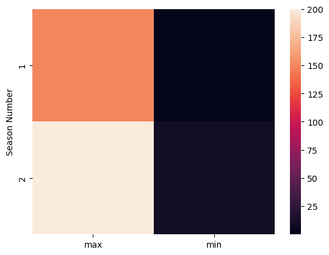

```python
 sns.heatmap(df_ac1.groupby(["Season Number"])["Total Deal Amount"].agg(["max","min"]));
```

### FIND THE MOST DEALING EPISODES OF BOTH THE SEASON

```python
best_episodes=df_ac.groupby(["Season Number",'Episode Number'])['Accepted Offer'].sum()
best_episodes.to_frame().sort_values(by=["Season Number","Accepted Offer"],ascending=False)
```

| Season Number | Episode Number | Accepted Offer |
| --- | --- | --- |
| 2 | 2 | 3.0 |
|  | 4 | 3.0 |
|  | 11 | 3.0 |
|  | 15 | 3.0 |
|  | 16 | 3.0 |
|  | 18 | 3.0 |
|  | 22 | 3.0 |
|  | 23 | 3.0 |
|  | 25 | 3.0 |
|  | 32 | 3.0 |
|  | 33 | 3.0 |
|  | 41 | 3.0 |
|  | 45 | 3.0 |
|  | 49 | 3.0 |
|  | 51 | 3.0 |
|  | 1 | 2.0 |
|  | 3 | 2.0 |
|  | 6 | 2.0 |
|  | 7 | 2.0 |
|  | 8 | 2.0 |
|  | 9 | 2.0 |
|  | 10 | 2.0 |
|  | 12 | 2.0 |
|  | 13 | 2.0 |
|  | 14 | 2.0 |
|  | 19 | 2.0 |
|  | 20 | 2.0 |
|  | 24 | 2.0 |
|  | 26 | 2.0 |
|  | 28 | 2.0 |

[output cut: 57 more lines]

### INSIGHTS :

In season 1 episode 1 is the most dealing episode

In season 2 episode 2 is the most dealing episode

### FIND THE MOST LIKING EPOISODES

```python
df_ac.groupby(["Season Number","Episode Number"])["Number of sharks in deal"].max().to_frame().sort_values(by=["Season Number","Number of sharks in deal"],ascending=False)
```

| Season Number | Episode Number | Number of sharks in deal |
| --- | --- | --- |
| 2 | 20 | 5.0 |
|  | 29 | 5.0 |
|  | 39 | 5.0 |
|  | 49 | 5.0 |
|  | 6 | 4.0 |
|  | 13 | 4.0 |
|  | 23 | 4.0 |
|  | 26 | 4.0 |
|  | 41 | 4.0 |
|  | 1 | 3.0 |
|  | 3 | 3.0 |
|  | 22 | 3.0 |
|  | 24 | 3.0 |
|  | 30 | 3.0 |
|  | 34 | 3.0 |
|  | 35 | 3.0 |
|  | 46 | 3.0 |
|  | 48 | 3.0 |
|  | 2 | 2.0 |
|  | 4 | 2.0 |
|  | 5 | 2.0 |
|  | 7 | 2.0 |
|  | 8 | 2.0 |
|  | 9 | 2.0 |
|  | 11 | 2.0 |
|  | 14 | 2.0 |
|  | 15 | 2.0 |
|  | 16 | 2.0 |
|  | 17 | 2.0 |
|  | 19 | 2.0 |

[output cut: 57 more lines]

### FIND THE MOST EXPENSIVE DEALING EPISODE

```python
expensive_episodes=df_ac.groupby(["Season Number",'Episode Number'])["Total Deal Amount"].sum().reset_index().sort_values(by=["Season Number","Total Deal Amount"],ascending=False)
expensive_episodes
```

|  | Season Number | Episode Number | Total Deal Amount |
| --- | --- | --- | --- |
| 56 | 2 | 20 | 300.00000 |
| 77 | 2 | 41 | 290.00000 |
| 62 | 2 | 26 | 250.00000 |
| 75 | 2 | 39 | 250.00000 |
| 58 | 2 | 22 | 225.00000 |
| 71 | 2 | 35 | 225.00000 |
| 51 | 2 | 15 | 222.00000 |
| 86 | 2 | 51 | 211.00000 |
| 38 | 2 | 2 | 200.00000 |
| 40 | 2 | 4 | 175.00000 |
| 54 | 2 | 18 | 175.00000 |
| 60 | 2 | 24 | 175.00000 |
| 61 | 2 | 25 | 175.00000 |
| 39 | 2 | 3 | 170.00000 |
| 48 | 2 | 12 | 160.00000 |
| 52 | 2 | 16 | 159.00000 |
| 59 | 2 | 23 | 155.00000 |
| 42 | 2 | 6 | 150.00000 |
| 83 | 2 | 48 | 150.00000 |
| 47 | 2 | 11 | 145.00000 |
| 55 | 2 | 19 | 145.00000 |
| 72 | 2 | 36 | 145.00000 |
| 64 | 2 | 28 | 140.00000 |
| 65 | 2 | 29 | 136.00000 |
| 37 | 2 | 1 | 130.00000 |
| 70 | 2 | 34 | 130.00000 |
| 84 | 2 | 49 | 130.00000 |
| 50 | 2 | 14 | 126.00000 |
| 46 | 2 | 10 | 125.00000 |
| 79 | 2 | 44 | 125.00000 |

[output cut: 57 more lines]

# Sharks Analysis

### HOW MANY SHARKS PARTICIPATED IN THE SHOW AND WHAT ARE THEIR NAMES?

```python
df.columns[35:-5:3]
```

```
Index(['Ashneer Investment Amount', 'Namita Investment Amount',
       'Anupam Investment Amount', 'Vineeta Investment Amount',
       'Aman Investment Amount', 'Peyush Investment Amount',
       'Ghazal Investment Amount', 'Amit Investment Amount'],
      dtype='object')
```

```python
sharks_names=[]
for i in df.columns[35:-5:3]:
    sharks=i.split(maxsplit=1)
    sharks_names.append(sharks[0])
print(len(sharks_names), "sharks participated \n")
print("following are the names of the sharks ",sharks_names)
```

```
8 sharks participated

following are the names of the sharks  ['Ashneer', 'Namita', 'Anupam', 'Vineeta', 'Aman', 'Peyush', 'Ghazal', 'Amit']
```

### HOW MANY SHARKS PARTICIPATED IN EACH SEASON ?

```python
df_1=df[df["Season Number"]==1]
for i in df.columns[35:-5:3]:
    if df_1[i].sum()==0:
        print(i.split(maxsplit=1)[0],"did not participated in season 1  \n")
    else:
        print(i.split(maxsplit=1)[0],"participated in season 1  \n")
```

```
Ashneer participated in season 1

Namita participated in season 1

Anupam participated in season 1

Vineeta participated in season 1

Aman participated in season 1

Peyush participated in season 1

Ghazal participated in season 1

Amit did not participated in season 1
```

```python
df_2=df[df["Season Number"]==2]
for i in df.columns[35:-5:3]:
    if df_2[i].sum()==0:
        print(i.split(maxsplit=1)[0],"did not participated in season 2 \n")
    else:
        print(i.split(maxsplit=1)[0],"participated in season 2  \n")
```

```
Ashneer did not participated in season 2

Namita participated in season 2

Anupam participated in season 2

Vineeta participated in season 2

Aman participated in season 2

Peyush participated in season 2

Ghazal did not participated in season 2

Amit participated in season 2
```

### INSIGHTS :

Amit did not participated in Season 1 and Ashneer and Ghazal did not participated in Season 2 . Rest all participated in both the seasons.

### HOW MUCH TOTAL AMOUNT EACH INVESTERS/SHARKS INVESTED IN THE DEALS?

```python
l=[]
for i in df.columns[35:-4:3]:
    s=df[i].sum()
    l.append(s)
```

```python
l
```

```
[539.3299999999999,
 2097.5102685,
 1451.1602684999998,
 1170.6,
 2510.040016,
 2210.3802525,
 159.9902525,
 800.91]
```

### INSIGHTS :

Aman invested the highest amount in the show

Ghazal invested the least amount in the show

### HOW MUCH EACH SHARK INVESTED IN EACH DEAL ?

```python
l_1=[]
for i in df_1.columns[35:-5:3]: ## season 1
    s=df_1[i].sum()

    l_1.append(s)

l_1
```

```
[539.3299999999999,
 708.6302685,
 536.3302685,
 363.62,
 896.990016,
 819.6502525,
 159.9902525,
 0.0]
```

```python
l_2=[]
for i in df_2.columns[35:-5:3]: ## season 1
    s=df_2[i].sum()

    l_2.append(s)

l_2
```

```
[0.0, 1388.88, 914.8299999999999, 806.98, 1613.05, 1390.73, 0.0, 800.91]
```

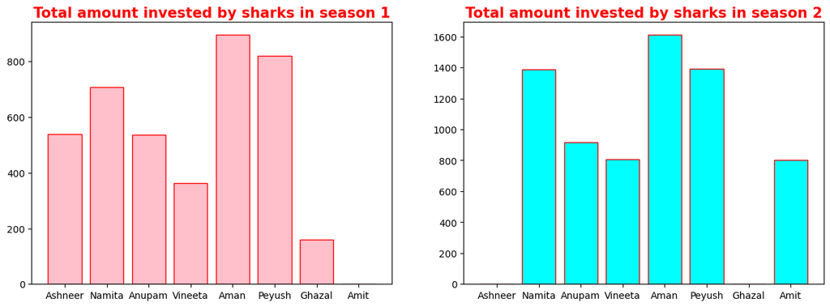

```python
plt.figure(figsize=(15,5))
plt.subplot(1,2,1)
plt.bar(sharks_names,l_1,color="pink",edgecolor="red")
plt.title("Total amount invested by sharks in season 1",fontweight="black",pad=5,size=15,color="Red")

plt.subplot(1,2,2)
plt.bar(sharks_names,l_2,color="cyan",edgecolor="red")
plt.title("Total amount invested by sharks in season 2",fontweight="black",pad=5,size=15,color="Red")
```